# Pattern Expected Waiting Time

```r
rm(list=ls(all=TRUE)) # Remove objects from environment
set.seed(12)
```

#### Book: Introduction to stochastic processes with R by Robert Dobrow

#### Example 3.33 on page 132

#### Summary:

#### Assume that successive occurrences of DNA nucleotides on a chromosome are modeled by a Markov chain.

```r
Ptilda <- matrix(NA,nr=4,nc=4)
colnames(Ptilda) <- rownames(Ptilda) <- c(1,2,3,4) # 1=A, 2=C, 3=G, 4=T
Ptilda[1,] <- c(0.3,0.2,0.3,0.2)  # Given an A in the 1st position
Ptilda[2,] <- c(0.4,0.3,0.1,0.2)  # Given a  C in the 1st position
Ptilda[3,] <- c(0.25,0.15,0.4,0.2)# Given a  G in the 1st position
Ptilda[4,] <- c(0.2,0.2,0.3,0.3)  # Given a  T in the 1st position
Ptilda
```

```
##      1    2   3   4
## 1 0.30 0.20 0.3 0.2
## 2 0.40 0.30 0.1 0.2
## 3 0.25 0.15 0.4 0.2
## 4 0.20 0.20 0.3 0.3
```

#### Consider searching sequentially across the chromosome until the pattern “accgc” first appears.

#### Solution: (From the book - Matrix approach)

```r
## The average number of nucleotides needed to reach a certain pattern
## An absorbing Markov chain ("PP") is constructed with transition matrix

t<-c(0.7,0.3,0,0,0,0)
a<-c(0.5,0.3,0.2,0,0,0)
ac<-c(0.3,0.4,0,0.3,0,0)
acc<-c(0.5,0.4,0,0,0.1,0)
accg<-c(0.6,0.25,0,0,0,0.15)
accgc<-c(0,0,0,0,0,1)
P<-matrix(c(t,a,ac,acc,accg,accgc),nr=6,nc=6,byrow = T)
P
```

```
##      [,1] [,2] [,3] [,4] [,5] [,6]
## [1,]  0.7 0.30  0.0  0.0  0.0 0.00
## [2,]  0.5 0.30  0.2  0.0  0.0 0.00
## [3,]  0.3 0.40  0.0  0.3  0.0 0.00
## [4,]  0.5 0.40  0.0  0.0  0.1 0.00
## [5,]  0.6 0.25  0.0  0.0  0.0 0.15
## [6,]  0.0 0.00  0.0  0.0  0.0 1.00
```

```r
Q<-P[1:5,1:5]
F= solve(diag(5)-Q)  ## F = (I-Q)^(-1)
F
```

```
##          [,1]      [,2]     [,3]     [,4]     [,5]
## [1,] 2201.852 1111.1111 222.2222 66.66667 6.666667
## [2,] 2198.519 1111.1111 222.2222 66.66667 6.666667
## [3,] 2190.185 1106.1111 222.2222 66.66667 6.666667
## [4,] 2167.407 1094.4444 218.8889 66.66667 6.666667
## [5,] 1870.741  944.4444 188.8889 56.66667 6.666667
```

```r
## average number of nucleotides needed to reach pattern accgc

sum(F[1,])
```

```
## [1] 3608.519
```

#### New Approach:

```r
## Function to Calculate Expected Waiting Time

ExpWaitTime <- function(labels = c(0,1), trials = 100, pattern = c(0,0,1,1,1), P = matrix(c(0.25, 0.25, 0.25, 0.25), nrow = 2, ncol = 2)){

  init <- as.vector(rep(1/length(labels),length(labels)))

  states <- 1:length(init)

  simlist <- c() # empty vector to store the sequence of simulated states
  simlist1 <- c() # empty vector to store the waiting times for each trial

  for (i in 1:trials) {

    simlist[1] <- sample(states,1,prob=init)#first state is chosen using the initial probabilities

    for (j in 2:length(pattern)) {
      simlist[j] <- sample(states,1,prob=P[simlist[j-1],])
    }#next states are sampled based on the transition matrix P. The state at position j is sampled based on the previous state j-1

#checking for the pattern
    STATE <- c()
    for (k in 1:length(pattern)) {
      STATE[k] = simlist[k]
    }

    n<-length(pattern)
    m<-length(pattern)

    temp=n-2
  #while loop continues generating new states and updating the sequence until the generated sequence matches the desired pattern
    while (!prod(labels[STATE]==pattern)){
      simlist[n+1] <- sample(states,1,prob=P[simlist[n],])
      for (l in 1:length(pattern)) {
        STATE[l] = simlist[n-temp+l-1]
      }
      n = n+1 #  length of the current sequence
      m = m+1 # total steps taken until the pattern appears.
    }

    simlist1[i] <- m

  }

  return(mean(simlist1)) # The function returns the mean of the waiting times across all trials, giving the expected waiting time until the desired pattern appears.

}
```

```r
# Note
# interested pattern: accgc == 12232

Time_DNA = ExpWaitTime(labels = c(1,2,3,4), trials = 1000, pattern = c(1,2,2,3,2), P = Ptilda)

Time_DNA
```

```
## [1] 3921.147
```

#### Fuzzyfying: (P = pR + (1 − p)A)

```r
## Function to find the the power (k^th power) of a given matrix

MatrixPower <- function(Matrix,k) {
    if (k == 0) return (diag(dim(Matrix)[1]))
    if (k == 1) return(Matrix)
    if (k > 1) return(Matrix %*% MatrixPower(Matrix, k-1))
}
```

#### Finding Stationary probabiities for a given matrix

```r
## Stationary distribution of discrete-time Markov chain
## (uses eigenvectors)

stationary <- function(mat){
  x = eigen(t(mat))$vectors[,1]
  return(as.double(x/sum(x)))
}
```

```r
FuzzyExpWaitTime <- function(labels = c(0,1), Ntrials = 100, pattern = c(0,0,1,1,1), Ptilda = matrix(c(0.25 ,0.25, 0.25, 0.25), nrow = 2, ncol = 2), alpha = seq(0.1,0.9,0.1), MMValue = 3608.52){

  ## Initializing minimum alpha
  alpha_min <- 0

  ## Initializing stochastic matrix (each entry is same and represent equal probability)
  A <- matrix(1/length(labels), nrow = length(labels), ncol = length(labels))

  ## Initializing temporary vector to save expected wait time for each alpha
  TempExpTime <- c()

  ## Maximum matrix power (l). For now we set maximum matrix power to length of the pattern we are untested in.
  l = length(pattern)

  ## Note: For each i (i.e. alpha value), we have 5 different powers (DNA example) of TempMatrix. Thus, to save all the matrices in correct order (alpha value and power), we need to save matrices within a matrix.

  ## Initializing a matrix which has a matrix in each entry
  m <- matrix(0, nrow = length(labels), ncol = length(labels))
  M <- matrix(list(m), nrow = length(alpha), ncol = l)

  ## For loop to calculate expected wait time and matrix power for each alpha
  for (i in 1:length(alpha)) {

    ## Fuzzyfying
    TempMatrix = alpha[i]*A + (1-alpha[i])*Ptilda

    ## Calculate expected wait time using "ExpWaitTime" for each alpha
    TempExpTime[i] <- ExpWaitTime(labels = labels, trials = Ntrials, pattern = pattern, P = TempMatrix)

    ## Finding matrix powers
    for (j in 1:l) {
      M[[i,j]] <- MatrixPower(TempMatrix,j)
    }

  }

  ## Finding alpha that gives the expected waiting time closer to the book value
  alpha_min <- alpha[which.min(abs(TempExpTime-MMValue))]

  ExpWaitTime <- TempExpTime[which.min(abs(TempExpTime-MMValue))]

  ## Return Values:
  ## 1. alpha that gives the expected waiting time closer to the book value
  ## 2. expected waiting time closer to the book value
  ## 3. matrix powers of TempMatrix for each alpha
  return(list(alpha_min=alpha_min, ExpWaitTime=ExpWaitTime, MatrixPower=M))

}
```

#### obtaining the alpha value that gives the expected waiting time closer to the book value (3608.52)

```r
FuzzyResults = FuzzyExpWaitTime(labels = c(1,2,3,4), Ntrials = 1000, pattern = c(1,2,2,3,2), P = Ptilda, alpha <- seq(0.2,0.3,0.001), MMValue = 3608.52)

## Print the alpha value that gives the expected waiting time closer to the book value
FuzzyResults$alpha_min
```

```
## [1] 0.203
```

```r
## Expected waiting time closer to the book value
FuzzyResults$ExpWaitTime
```

```
## [1] 2922.575
```

```r
## Print the matrix power of 5 for 1st alpha value (i.e. alpha = 0.1)
FuzzyResults$MatrixPower[1,5]
```

```
## [[1]]
##           1         2         3         4
## 1 0.2779263 0.2161864 0.2776272 0.2282601
## 2 0.2779787 0.2162388 0.2775223 0.2282601
## 3 0.2779001 0.2161602 0.2776796 0.2282601
## 4 0.2779230 0.2161864 0.2776272 0.2282634
```

```r
## Print the matrix power of 4 for 3rd alpha value (i.e. alpha = 0.3)
FuzzyResults$MatrixPower[3,4]
```

```
## [[1]]
##           1         2         3         4
## 1 0.2778505 0.2162612 0.2775777 0.2283107
## 2 0.2781749 0.2165856 0.2769289 0.2283107
## 3 0.2776883 0.2160989 0.2779021 0.2283107
## 4 0.2778099 0.2162612 0.2775777 0.2283512
```

#### Stationary probabilities

```r
LongTermProb_DNA = stationary(Ptilda)
LongTermProb_DNA
```

```
## [1] 0.2840278 0.2062500 0.2875000 0.2222222
```

#### Example 2.26 (on Page 76)

#### In computer security applications, a honeypot is a trap set on a network to detect and counteract computer hackers. Honeypot data are studied in Kimou et al. (2010) using Markov chains. The authors obtain honeypot data from a central database and observe attacks against four computer ports—80, 135, 139, and 445—over 1 year. The ports are the states of a Markov chain along with a state corresponding to no port is attacked. Weekly data are monitored, and the port most often attacked during the week is recorded. The estimated Markov transition matrix for weekly attacks is

```r
Ptilda <- matrix(0, nrow = 5, ncol = 5)
colnames(Ptilda) <- rownames(Ptilda) <- c(1,2,3,4,5) # 1=80, 2=135, 3=139, 4=445, 5=No attack
Ptilda[1,] <- c(0, 0, 0, 0, 1)  # Given an 80 in the 1st position
Ptilda[2,] <- c(0, 8/13, 3/13, 1/13, 1/13)  # Given a 135 in the 1st position
Ptilda[3,] <- c(1/16, 3/16, 3/8, 1/4, 1/8) # Given a 139 in the 1st position
Ptilda[4,] <- c(0, 1/11, 4/11, 5/11, 1/11)  # Given a 445 in the 1st position
Ptilda[5,] <- c(0, 1/8, 1/2, 1/8, 1/4)  # Given a No attack in the 1st position
Ptilda
```

```
##        1          2         3          4          5
## 1 0.0000 0.00000000 0.0000000 0.00000000 1.00000000
## 2 0.0000 0.61538462 0.2307692 0.07692308 0.07692308
## 3 0.0625 0.18750000 0.3750000 0.25000000 0.12500000
## 4 0.0000 0.09090909 0.3636364 0.45454545 0.09090909
## 5 0.0000 0.12500000 0.5000000 0.12500000 0.25000000
```

```r
round(MatrixPower(Ptilda,2),3)
```

```
##       1     2     3     4     5
## 1 0.000 0.125 0.500 0.125 0.250
## 2 0.014 0.439 0.295 0.150 0.102
## 3 0.023 0.224 0.337 0.237 0.178
## 4 0.023 0.177 0.368 0.316 0.116
## 5 0.031 0.213 0.387 0.223 0.146
```

#### Starting from state no attack (0,0,0,0,1), in two weeks Which are the least likely attacked ports after 2 weeks? Port 80, and the corresponding probability is 0.031 (entry row 5 column 1)

#### Starting from state no attack (0,0,0,0,1), in two weeks Which are the most likely attacked ports after 2 weeks? Port 139, and the corresponding probability is 0.387 (entry row 5 column 3)

#### Finding Expected Waiting Time for no attacks for 4 consecutive weeks

```r
WaitTimeSecurity <- ExpWaitTime(labels = c(1,2,3,4,5), trials = 1000, pattern = c(5,5,5,5), P = Ptilda)
WaitTimeSecurity
```

```
## [1] 593.252
```

#### Matrix appraoch

```r
## An absorbing Markov chain is constructed with transition matrix
## Pattern interested: (5555)
## "A" correspond to null event

A = c(3/4,1/4,0,0,0)
NA1 = c(3/4,0,1/4,0,0)
NA2 = c(3/4,0,0,1/4,0)
NA3 = c(3/4,0,0,0,1/4)
NA4 = c(0,0,0,0,1)
P <- matrix(c(A,NA1,NA2,NA3,NA4),nr=5,nc=5,byrow = T)
P
```

```
##      [,1] [,2] [,3] [,4] [,5]
## [1,] 0.75 0.25 0.00 0.00 0.00
## [2,] 0.75 0.00 0.25 0.00 0.00
## [3,] 0.75 0.00 0.00 0.25 0.00
## [4,] 0.75 0.00 0.00 0.00 0.25
## [5,] 0.00 0.00 0.00 0.00 1.00
```

```r
Q<-P[1:4,1:4]
F= solve(diag(4)-Q)  ## F = (I-Q)^(-1)
F
```

```
##      [,1] [,2] [,3] [,4]
## [1,]  256   64   16    4
## [2,]  252   64   16    4
## [3,]  240   60   16    4
## [4,]  192   48   12    4
```

```r
## Expected Waiting Time (Matrix Approach) for 5555. i.e. no attacks for a month
MatrixMethod_ComSecirity = 256+64+16+4
MatrixMethod_ComSecirity
```

```
## [1] 340
```

#### Fuzzyfying

```r
FuzzySecurity <- FuzzyExpWaitTime(labels = c(1,2,3,4,5), Ntrials = 20, pattern = c(5,5,5,5), Ptilda = Ptilda, alpha <- seq(0.3,0.4,0.001), MMValue = 340)
```

```r
FuzzySecurity$alpha_min
```

```
## [1] 0.374
```

```r
FuzzySecurity$ExpWaitTime
```

```
## [1] 348.75
```

```r
#FuzzySecurity$MatrixPower[192,4] # conditional probabilities after 4 weeks for alpha = 0.391
FuzzySecurity$MatrixPower
```

[output not shown]

[output cut: 87 more lines]

#### Starting from state no attack, in 4 weeks Which are the least likely attacked ports? Port 80, and the corresponding probability is 0.08891714 (entry row 5 column 1) with alpha equals 0.391

#### Starting from state no attack, in 4 weeks Which are the most likely attacked ports? Port 139, and the corresponding probability is 0.2817521 (entry row 5 column 3) with alpha equals 0.391

#### Stationary probabilities

```r
LongTermProb_ComSeq = stationary(Ptilda)
LongTermProb_ComSeq
```

```
## [1] 0.02146667 0.26693333 0.34346667 0.22733333 0.14080000
```

#### Successive Occurrences of DNA Nucleotides

#### dataset bnrf1ebv (Nucleotide sequence - BNRF1 Epstein-Barr)

```r
library(markovchain)
library(astsa)
library(seqinr)
## bnrf1ebv, bnrf1hvs - with numbers  (***and EBV - with letters)
data = bnrf1ebv

#data = bnrf1hvs
#data = dna2vector(EBV)

for(i in 1:length(data)){
  if(data[i]==1){
    data[i] = "A"
  }
  else if(data[i]==2){
    data[i] = "C"
  }
  else if(data[i]==3){
    data[i] = "G"
  }
  else{
    data[i] = "T"
  }
}
```

#### Base Proportions of Nucleotide in bnrf1ebv

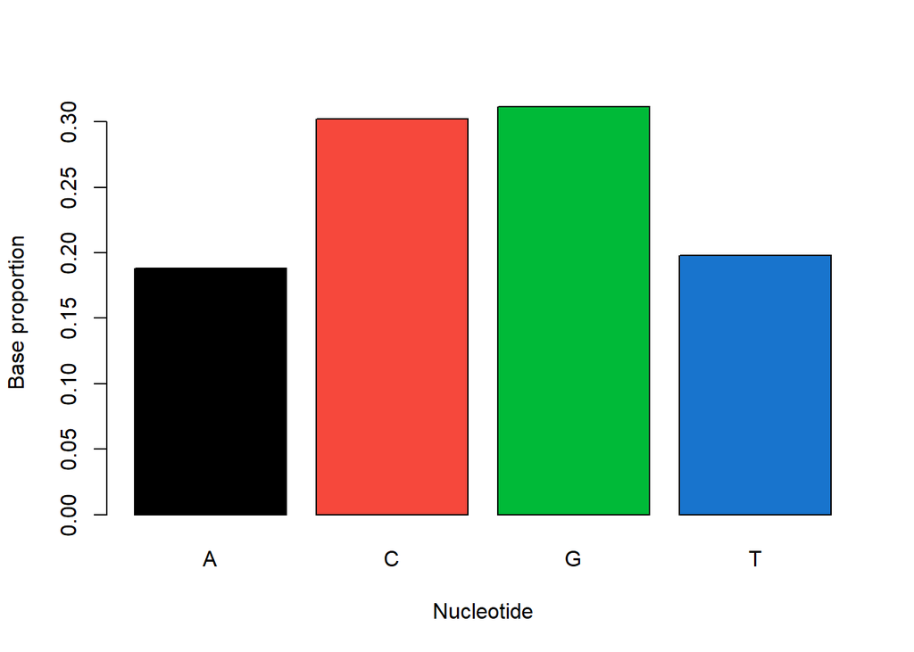

```r
alp <- c("A","C","G","T")
zeroOrderFreq <- count(data,1,alphabet=alp,freq=TRUE)
barplot(zeroOrderFreq,col=1:4,
        #main="Compositional bias of each nucleotide",
        xlab="Nucleotide",
        ylab="Base proportion")
```

#### Base Proportions of dinucleotide in bnrf1ebv

```r
library(plotly)
count(data,2,alphabet=alp,freq=FALSE)
```

```
##
##  AA  AC  AG  AT  CA  CC  CG  CT  GA  GC  GG  GT  TA  TC  TG  TT
## 130 219 247 148 283 380 262 270 244 367 417 203  86 229 306 162
```

```r
zeroOrderFreqDin <- count(data,2,alphabet=alp,freq=TRUE)
round(zeroOrderFreqDin,3)
```

```
##
##    AA    AC    AG    AT    CA    CC    CG    CT    GA    GC    GG    GT    TA
## 0.033 0.055 0.062 0.037 0.072 0.096 0.066 0.068 0.062 0.093 0.105 0.051 0.022
##    TC    TG    TT
## 0.058 0.077 0.041
```

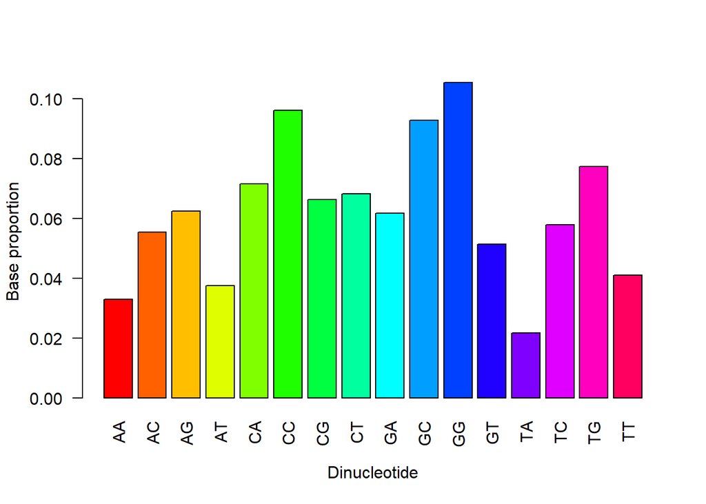

```r
barplot(zeroOrderFreqDin,col=rainbow(16),
        #main="Compositional bias of each dinucleotide",
        xlab="Dinucleotide",
        ylab="Base proportion", las = 2)
```

```r
#data = bnrf1ebv
#xdata = dna2vector(data)
#u = specenv(xdata, spans=c(7,7))
```

#### Dynamic Spectral Enevelop for the data

```r
library(astsa)
library(seqinr)
   u = factor(bnrf1ebv) #3954
#u = factor(bnrf1hvs)
   head(u)
```

```
## [1] 1 4 3 3 1 1
## Levels: 1 2 3 4
```

```r
   tail(u)
```

```
## [1] 4 2 2 3 1 3
## Levels: 1 2 3 4
```

```r
x = model.matrix(~u-1)[,1:3]
dim(x) # 3954x3
```

```
## [1] 3954    3
```

```r
Var = var(x)
dim(Var) #3x3
```

```
## [1] 3 3
```

```r
xspec = mvspec(x, spans=c(7,7), plot=FALSE) # spectral matrices are an array
length(xspec)
```

```
## [1] 19
```

```r
# called fxx
fxxr = Re(xspec$fxx) # fxxr is real(fxx)
#head(fxxr)
#tail(fxxr)
# first, input the data as factors and then
# make an indicator matrix
# var-cov matrix
```

```r
Var
```

```
##             u1          u2          u3
## u1  0.15279688 -0.05688233 -0.05864354
## u2 -0.05688233  0.21093863 -0.09419224
## u3 -0.05864354 -0.09419224  0.21455337
```

```r
ev = eigen(Var)
ev$vectors
```

```
##             [,1]       [,2]       [,3]
## [1,] -0.01707597  0.7760857 -0.6303962
## [2,] -0.69488697 -0.4625458 -0.5506210
## [3,]  0.71891620 -0.4286517 -0.5471903
```

```r
Q = ev$vectors%*%diag(1/sqrt(ev$values))%*%t(ev$vectors)
```

#### compute spectral envelope and scale vectors

```r
num = xspec$n.used
num
```

```
## [1] 4000
```

```r
nfreq = length(xspec$freq)
nfreq
```

```
## [1] 2000
```

```r
specenv = matrix(0,nfreq,1)
beta = matrix(0,nfreq,3)
# effective sample size
# number of frequencies
# initialize the spectral envelope
# initialize the scale vectors
for (k in 1:nfreq){
ev = eigen(2*Q%*%fxxr[,,k]%*%Q/num) # get evalues of normalized spectral
specenv[k] = ev$values[1]
b = Q%*%ev$vectors[,1]
beta[k,] = b/sqrt(sum(b^2))
}
# b #3x1
#         [,1]
#[1,] 0.9360134
#[2,] 2.7509599
#[3,] 1.7859554
#beta
dim(beta)  #2000x3
```

```
## [1] 2000    3
```

```r
##--- dynamic part ---##
z = matrix(0,250,8)
output2 = array(0, dim=c(250,5,8))
colnames(output2) = c("freq","specenv","A", "C", "G")
for (j in 1:8){
ind = (500*(j-1)+1):(500*j)
if (j==8) ind=3501:length(bnrf1ebv)
xx = x[ind,] # select subsequence -- the rest of the this part is the same
# as above
Var = var(xx)
xspec = mvspec(xx, spans=c(3,3), plot=FALSE)
fxxr = Re(xspec$fxx)
ev = eigen(Var)
Q = ev$vectors%*%diag(1/sqrt(ev$values))%*%t(ev$vectors)
num = xspec$n.used
nfreq = length(xspec$freq)
frequency = (0:(nfreq-1))/num
specenv = matrix(0, nfreq, 1)
beta = matrix(0, nfreq, 3)
for (k in 1:nfreq){
ev = eigen(2*Q%*%fxxr[,,k]%*%Q/num)
specenv[k] = ev$values[1]
b = Q%*%ev$vectors[,1]
beta[k,] = b/sqrt(sum(b^2))
}
if(j<8) { z[,j] = specenv; output2[,,j] = cbind(frequency, specenv, beta) }
if(j==8) { z[1:240,8] = specenv; output2[1:240,,j] = cbind(frequency, specenv,
beta) }
}
```

```r
#--- output and graphics (results in output2)---#
zz = 100*t(z) # zz is 8x250
rowss = rep(1:8, each=2)
zz = zz[rowss,] # now it’s 16x250
# threshold
m = xspec$kernel$m
nuinv = sqrt(sum(xspec$kernel[-m:m]^2))
thresh=100*(2/num)*exp(qnorm(.995)*nuinv)
#dev.new(height = 5)
par(mar=c(3,3,3,1), mgp=c(1.6,.6,0))
xa = 0:249/500
ya1 = 1736+500*0:8
rowss = c(1, rep(2:8, each=2), 9)
ya = ya1[rowss]
ya[seq(2,16,by=2)] = ya[seq(2,16,by=2)]-.5
levs = thresh*seq(0, 4.5, by=.5)
colr = gray(c(10,9,5,4.5,4,3,2,1,0)/10)

jpeg("contourplot.jpg", width = 800, height = 600)

contour(ya, xa, zz, xlab="base pair", ylab="frequency", levels=levs, col=colr,
main="Epstein-Barr BNRF1", lwd=2, drawlabels=FALSE)

abline(v = ya1, lty = 2, col = "gray")

dev.off()
```

```r
## transition probability matrix
PtildaTemp = markovchainFit(data)

Ptilda = markovchainFit(data)$estimate
Ptilda = as.matrix(Ptilda[1:4])
round(Ptilda,3)
```

```
##       A     C     G     T
## A 0.175 0.294 0.332 0.199
## C 0.237 0.318 0.219 0.226
## G 0.198 0.298 0.339 0.165
## T 0.110 0.292 0.391 0.207
```

```r
 ## Check lower end and upper end matrices
Ptilda_lower = markovchainFit(data)$lowerEndpointMatrix
round(Ptilda_lower,3)
```

```
##       A     C     G     T
## A 0.145 0.255 0.291 0.167
## C 0.209 0.286 0.193 0.199
## G 0.173 0.268 0.306 0.142
## T 0.087 0.255 0.347 0.175
```

```r
Ptilda_upper = markovchainFit(data)$upperEndpointMatrix
round(Ptilda_upper,3)
```

```
##       A     C     G     T
## A 0.205 0.333 0.373 0.231
## C 0.264 0.350 0.246 0.253
## G 0.223 0.329 0.371 0.188
## T 0.133 0.330 0.435 0.239
```

#### Matrix Approach

```r
## pattern matrix for bnrf1ebv as accgc the pattern
t<-c(0.825,0.175,0,0,0,0)
a<-c(0.531,0.175,0.294,0,0,0)
ac<-c(0.445,0.237,0,0.318,0,0)
acc<-c(0.544,0.237,0,0,0.219,0)
accg<-c(0.504,0.198,0,0,0,0.298)
accgc<-c(0,0,0,0,0,1)

## pattern matrix for bnrf1hvs as accgc the pattern
# t<-c(0.668,0.332,0,0,0,0)
# a<-c(0.474,0.332,0.194,0,0,0)
# ac<-c(0.422,0.391,0,0.187,0,0)
# acc<-c(0.555,0.391,0,0,0.054,0)
# accg<-c(0.485,0.294,0,0,0,0.221)
# accgc<-c(0,0,0,0,0,1)
P<-matrix(c(t,a,ac,acc,accg,accgc),nr=6,nc=6,byrow = T)
P
```

```
##       [,1]  [,2]  [,3]  [,4]  [,5]  [,6]
## [1,] 0.825 0.175 0.000 0.000 0.000 0.000
## [2,] 0.531 0.175 0.294 0.000 0.000 0.000
## [3,] 0.445 0.237 0.000 0.318 0.000 0.000
## [4,] 0.544 0.237 0.000 0.000 0.219 0.000
## [5,] 0.504 0.198 0.000 0.000 0.000 0.298
## [6,] 0.000 0.000 0.000 0.000 0.000 1.000
```

```r
Q<-P[1:5,1:5]
F= solve(diag(5)-Q)  ## F = (I-Q)^(-1)
F
```

```
##          [,1]     [,2]     [,3]     [,4]     [,5]
## [1,] 682.8423 163.8948 48.18507 15.32285 3.355705
## [2,] 677.1280 163.8948 48.18507 15.32285 3.355705
## [3,] 666.8073 160.4934 48.18507 15.32285 3.355705
## [4,] 636.6766 153.1987 45.04042 15.32285 3.355705
## [5,] 478.2239 115.0541 33.82592 10.75664 3.355705
```

```r
## average number of nucleotides needed to reach pattern accgc IN bnrf1ebv

round(682.8423 + 163.8948 + 48.18507 + 15.32285 + 3.355705,3)
```

```
## [1] 913.601
```

```r
## average number of nucleotides needed to reach pattern accgc IN bnrf1hvs

round(sum(F[1,]),3)
```

```
## [1] 913.601
```

#### Fuzzy pattern mining algorithm

```r
FuzzyResultsDNA = FuzzyExpWaitTime(labels = c(1,2,3,4), Ntrials = 1000, pattern = c(1,2,2,3,2), P = Ptilda, alpha <- seq(0,1,0.001), MMValue = 913.601) ##mm value is matrix approach value

## Print the alpha value that gives the expected waiting time closer to the book value
FuzzyResultsDNA$alpha_min
```

```
## [1] 0.185
```

```r
## Expected waiting time closer to the book value
FuzzyResultsDNA$ExpWaitTime
```

```
## [1] 913.553
```

```r
## Print the matrix power of 5 for 1st alpha value (i.e. alpha = 0.1)
FuzzyResultsDNA$MatrixPower[1,5]
```

```
## [[1]]
##           A         C         G         T
## A 0.1879650 0.3023030 0.3116631 0.1980688
## C 0.1879658 0.3023031 0.3116627 0.1980685
## G 0.1879649 0.3023030 0.3116634 0.1980687
## T 0.1879646 0.3023030 0.3116634 0.1980690
```

```r
## Print the matrix power of 4 for 3rd alpha value (i.e. alpha = 0.3)
FuzzyResultsDNA$MatrixPower[3,4]
```

```
## [[1]]
##           A         C         G         T
## A 0.1880757 0.3021953 0.3115541 0.1981749
## C 0.1880741 0.3021958 0.3115633 0.1981668
## G 0.1880687 0.3021949 0.3115589 0.1981775
## T 0.1880765 0.3021952 0.3115491 0.1981792
```

#### Observe and Estimated proportions and counts

```r
## Observe counts
count(data,1,alphabet=alp,freq=FALSE)
```

```
##
##    A    C    G    T
##  744 1195 1232  783
```

```r
## Observe Proportions
zeroOrderFreq <- count(data,1,alphabet=alp,freq=TRUE)
round(zeroOrderFreq,3)
```

```
##
##     A     C     G     T
## 0.188 0.302 0.312 0.198
```

```r
## Estimated proportions
LongTermProb_DNA = stationary(Ptilda)
round(LongTermProb_DNA,3)
```

```
## [1] 0.188 0.302 0.312 0.198
```

```r
## Estimated counts
round(LongTermProb_DNA*length(data),3)
```

```
## [1]  743.214 1195.306 1232.316  783.164
```

```r
## Estimated counts
## LongTermProb_DNA*3954
## 743.2140 1195.3063 1232.3160  783.1637

## Estimated Proportions
## 0.1879651 0.3023030 0.3116631 0.1980687
## Note they are close - Add a table to WP
```

#### Example 3-Financial Application (Stocks)

```r
start.date = '2017-01-01'
end.date = '2022-11-30'
 getSymbols(c("^GSPC","^VIX","GOOG","AAPL"), src = "yahoo", from = start.date, to = end.date)
```

```
## [1] "GSPC" "VIX"  "GOOG" "AAPL"
```

```r
#
 stocks <- merge(SP500 = GSPC[, "GSPC.Close"],VIX = VIX[, "VIX.Close"],GOOG = GOOG[, "GOOG.Close"],AAPL = AAPL[, "AAPL.Close"])
#
 head(stocks)
```

```
##            GSPC.Close VIX.Close GOOG.Close AAPL.Close
## 2017-01-03    2257.83     12.85    39.3070    29.0375
## 2017-01-04    2270.75     11.85    39.3450    29.0050
## 2017-01-05    2269.00     11.67    39.7010    29.1525
## 2017-01-06    2276.98     11.32    40.3075    29.4775
## 2017-01-09    2268.90     11.56    40.3325    29.7475
## 2017-01-10    2268.90     11.49    40.2395    29.7775
```

```r
assets <- c('SP500','VIX','GOOG','AAPL')
xy <- stocks
colnames(xy) <- assets
##Calculate log returns

log_return<-xy %>% log %>% diff #log returns
#return<- exp (log_return) - 1 #returns
head(log_return)
```

```
##                    SP500          VIX          GOOG         AAPL
## 2017-01-03            NA           NA            NA           NA
## 2017-01-04  0.0057059638 -0.081015941  0.0009663331 -0.001119911
## 2017-01-05 -0.0007709676 -0.015306447  0.0090074487  0.005072478
## 2017-01-06  0.0035107892 -0.030450407  0.0151611477  0.011086614
## 2017-01-09 -0.0035549055  0.020979854  0.0006200776  0.009117785
## 2017-01-10  0.0000000000 -0.006073828 -0.0023085529  0.001008003
```

```r
tail(log_return)
```

```
##                   SP500         VIX        GOOG         AAPL
## 2022-11-22  0.013488606 -0.04903615  0.01553148  0.014554724
## 2022-11-23  0.005897266 -0.04515659  0.01519273  0.005908828
## 2022-11-24           NA          NA          NA           NA
## 2022-11-25           NA          NA          NA           NA
## 2022-11-28 -0.015564697  0.08011771 -0.01392850 -0.026615325
## 2022-11-29 -0.001593134 -0.01451271 -0.00845117 -0.021375095
```

```r
nrow(log_return)
```

```
## [1] 1541
```

```r
##Creating signs
signal <- list()
for (i in 1:length(assets)){
signal [[i]] <- ifelse(as.data.frame(log_return[, i]) >= 0, 1, -1)#if the ith col of logreturns >=0 (positive) then create signal with 1,
  #otherwise (logreturns<0) signal=-1
}
signal<-as.data.frame(do.call(cbind, signal))
colnames(signal) <- assets
head(signal)
```

```
##            SP500 VIX GOOG AAPL
## 2017-01-03    NA  NA   NA   NA
## 2017-01-04     1  -1    1   -1
## 2017-01-05    -1  -1    1    1
## 2017-01-06     1  -1    1    1
## 2017-01-09    -1   1    1    1
## 2017-01-10     1  -1   -1    1
```

```r
##Creating markov matrix
markovmatrix <-list()
for (j in 1:length(assets)){
seq1 = na.omit (as.vector (signal[, j]))
markovmatrix[[j]] <-markovchainFit(seq1)$estimate
}
asset_number<-3
assets[asset_number]
```

```
## [1] "GOOG"
```

```r
stock<-as.matrix(markovmatrix[[asset_number]][1:2])# goog. Change first argument to get matrix for each CC. i.e.markovmatrix[[2]][1:2] for vix.
stock
```

```
##           -1         1
## -1 0.4627093 0.5372907
## 1  0.4561856 0.5438144
```

```r
colnames(stock) <- c(0,1) #Assign names to the columns
rownames(stock) <- c(0,1)
 stock
```

```
##           0         1
## 0 0.4627093 0.5372907
## 1 0.4561856 0.5438144
```

#### Matrix approach- pattern 0101-aapl

```r
phi<-c(0.552,0.448,0,0,0)
s1<-c(0,0.448,0.552,0,0)
s2<-c(0.521,0,0,0.479,0)
s3<-c(0,0.448,0,0,0.552)
s4<-c(0,0,0,0,1)
 P<-matrix(c(phi,s1,s2,s3,s4),nr=5,nc=5,byrow = T)
 P
```

```
##       [,1]  [,2]  [,3]  [,4]  [,5]
## [1,] 0.552 0.448 0.000 0.000 0.000
## [2,] 0.000 0.448 0.552 0.000 0.000
## [3,] 0.521 0.000 0.000 0.479 0.000
## [4,] 0.000 0.448 0.000 0.000 0.552
## [5,] 0.000 0.000 0.000 0.000 1.000
```

```r
Q<-P[1:4,1:4]
 F= solve(diag(4)-Q)  ## F = (I-Q)^(-1)
 F
```

```
##          [,1]     [,2]     [,3]     [,4]
## [1,] 6.630446 6.851511 3.782034 1.811594
## [2,] 4.398303 6.851511 3.782034 1.811594
## [3,] 4.398303 5.039916 3.782034 1.811594
## [4,] 1.970440 3.069477 1.694351 1.811594
```

#### Matrix approach- pattern 0101-goog

```r
phi<-c(0.543,0.457,0,0,0)
s1<-c(0,0.457,0.543,0,0)
s2<-c(0.546,0,0,0.454,0)
s3<-c(0,0.457,0,0,0.543)
s4<-c(0,0,0,0,1)
 P<-matrix(c(phi,s1,s2,s3,s4),nr=5,nc=5,byrow = T)
 P
```

```
##       [,1]  [,2]  [,3]  [,4]  [,5]
## [1,] 0.543 0.457 0.000 0.000 0.000
## [2,] 0.000 0.457 0.543 0.000 0.000
## [3,] 0.546 0.000 0.000 0.454 0.000
## [4,] 0.000 0.457 0.000 0.000 0.543
## [5,] 0.000 0.000 0.000 0.000 1.000
```

```r
Q<-P[1:4,1:4]
 F= solve(diag(4)-Q)  ## F = (I-Q)^(-1)
 F
```

```
##          [,1]     [,2]     [,3]     [,4]
## [1,] 7.034601 7.470411 4.056433 1.841621
## [2,] 4.846417 7.470411 4.056433 1.841621
## [3,] 4.846417 5.628790 4.056433 1.841621
## [4,] 2.214812 3.413978 1.853790 1.841621
```

#### Matrix approach- pattern 0001-sp500

```r
phi<-c(0.569,0.431,0,0,0)
s1<-c(0.569,0,0.431,0,0)
s2<-c(0.569,0,0,0.431,0)
s3<-c(0,0,0,0.431,0.569)
s4<-c(0,0,0,0,1)
 P<-matrix(c(phi,s1,s2,s3,s4),nr=5,nc=5,byrow = T)
 P
```

```
##       [,1]  [,2]  [,3]  [,4]  [,5]
## [1,] 0.569 0.431 0.000 0.000 0.000
## [2,] 0.569 0.000 0.431 0.000 0.000
## [3,] 0.569 0.000 0.000 0.431 0.000
## [4,] 0.000 0.000 0.000 0.431 0.569
## [5,] 0.000 0.000 0.000 0.000 1.000
```

```r
Q<-P[1:4,1:4]
 F= solve(diag(4)-Q)  ## F = (I-Q)^(-1)
 F
```

```
##           [,1]     [,2]     [,3]     [,4]
## [1,] 12.490165 5.383261 2.320186 1.757469
## [2,] 10.169980 5.383261 2.320186 1.757469
## [3,]  7.106904 3.063076 2.320186 1.757469
## [4,]  0.000000 0.000000 0.000000 1.757469
```

```r
 sum(F[1,])
```

```
## [1] 21.95108
```

#### Matrix approach- pattern 0010-sp500

```r
phi<-c(0.569,0.431,0,0,0)
s1<-c(0.569,0,0.431,0,0)
s2<-c(0,0,0.431,0.569,0)
s3<-c(0.538,0,0,0,0.462)
s4<-c(0,0,0,0,1)
 P<-matrix(c(phi,s1,s2,s3,s4),nr=5,nc=5,byrow = T)
 P
```

```
##       [,1]  [,2]  [,3]  [,4]  [,5]
## [1,] 0.569 0.431 0.000 0.000 0.000
## [2,] 0.569 0.000 0.431 0.000 0.000
## [3,] 0.000 0.000 0.431 0.569 0.000
## [4,] 0.538 0.000 0.000 0.000 0.462
## [5,] 0.000 0.000 0.000 0.000 1.000
```

```r
Q<-P[1:4,1:4]
 F= solve(diag(4)-Q)  ## F = (I-Q)^(-1)
 F
```

```
##           [,1]     [,2]     [,3]     [,4]
## [1,] 11.652081 5.022047 3.804046 2.164502
## [2,]  9.331895 5.022047 3.804046 2.164502
## [3,]  6.268819 2.701861 3.804046 2.164502
## [4,]  6.268819 2.701861 2.046577 2.164502
```

```r
  sum(F[1,])
```

```
## [1] 22.64268
```

#### Matrix approach- pattern 0100-sp500

```r
phi<-c(0.569,0.431,0,0,0)
s1<-c(0,0.431,0.569,0,0)
s2<-c(0.538,0,0,0.462,0)
s3<-c(0,0,0.569,0,0.431)
s4<-c(0,0,0,0,1)
 P<-matrix(c(phi,s1,s2,s3,s4),nr=5,nc=5,byrow = T)
 P
```

```
##       [,1]  [,2]  [,3]  [,4]  [,5]
## [1,] 0.569 0.431 0.000 0.000 0.000
## [2,] 0.000 0.431 0.569 0.000 0.000
## [3,] 0.538 0.000 0.000 0.462 0.000
## [4,] 0.000 0.000 0.569 0.000 0.431
## [5,] 0.000 0.000 0.000 0.000 1.000
```

```r
Q<-P[1:4,1:4]
 F= solve(diag(4)-Q)  ## F = (I-Q)^(-1)
 F
```

```
##          [,1]     [,2]     [,3]     [,4]
## [1,] 8.589005 6.505907 5.022047 2.320186
## [2,] 6.268819 6.505907 5.022047 2.320186
## [3,] 6.268819 4.748438 5.022047 2.320186
## [4,] 3.566958 2.701861 2.857545 2.320186
```

```r
 sum(F[1,])
```

```
## [1] 22.43714
```

#### Matrix approach- pattern 0011-sp500

```r
phi<-c(0.569,0.431,0,0,0)
s1<-c(0.569,0,0.431,0,0)
s2<-c(0,0,0.431,0.569,0)
s3<-c(0,0.462,0,0,0.538)
s4<-c(0,0,0,0,1)
 P<-matrix(c(phi,s1,s2,s3,s4),nr=5,nc=5,byrow = T)
 P
```

```
##       [,1]  [,2]  [,3]  [,4]  [,5]
## [1,] 0.569 0.431 0.000 0.000 0.000
## [2,] 0.569 0.000 0.431 0.000 0.000
## [3,] 0.000 0.000 0.431 0.569 0.000
## [4,] 0.000 0.462 0.000 0.000 0.538
## [5,] 0.000 0.000 0.000 0.000 1.000
```

```r
Q<-P[1:4,1:4]
 F= solve(diag(4)-Q)  ## F = (I-Q)^(-1)
 F
```

```
##          [,1]     [,2]     [,3]     [,4]
## [1,] 8.013635 4.312613 3.266671 1.858736
## [2,] 5.693449 4.312613 3.266671 1.858736
## [3,] 2.630374 1.992427 3.266671 1.858736
## [4,] 2.630374 1.992427 1.509202 1.858736
```

```r
 sum(F[1,])
```

```
## [1] 17.45166
```

#### Matrix approach- pattern 0101-sp500

```r
phi<-c(0.569,0.431,0,0,0)
s1<-c(0,0.431,0.569,0,0)
s2<-c(0.538,0,0,0.462,0)
s3<-c(0,0.431,0,0,0.569)
s4<-c(0,0,0,0,1)
 P<-matrix(c(phi,s1,s2,s3,s4),nr=5,nc=5,byrow = T)
 P
```

```
##       [,1]  [,2]  [,3]  [,4]  [,5]
## [1,] 0.569 0.431 0.000 0.000 0.000
## [2,] 0.000 0.431 0.569 0.000 0.000
## [3,] 0.538 0.000 0.000 0.462 0.000
## [4,] 0.000 0.431 0.000 0.000 0.569
## [5,] 0.000 0.000 0.000 0.000 1.000
```

```r
Q<-P[1:4,1:4]
 F= solve(diag(4)-Q)  ## F = (I-Q)^(-1)
 F
```

```
##          [,1]     [,2]     [,3]     [,4]
## [1,] 7.068624 6.685494 3.804046 1.757469
## [2,] 4.748438 6.685494 3.804046 1.757469
## [3,] 4.748438 4.928025 3.804046 1.757469
## [4,] 2.046577 2.881448 1.639544 1.757469
```

```r
 sum(F[1,])
```

```
## [1] 19.31563
```

#### Matrix approach- pattern 1100-sp500

```r
phi<-c(0.431,0.569,0,0,0)
s1<-c(0.462,0,0.538,0,0)
s2<-c(0,0,0.538,0.462,0)
s3<-c(0,0.569,0,0,0.431)
s4<-c(0,0,0,0,1)
 P<-matrix(c(phi,s1,s2,s3,s4),nr=5,nc=5,byrow = T)
 P
```

```
##       [,1]  [,2]  [,3]  [,4]  [,5]
## [1,] 0.431 0.569 0.000 0.000 0.000
## [2,] 0.462 0.000 0.538 0.000 0.000
## [3,] 0.000 0.000 0.538 0.462 0.000
## [4,] 0.000 0.569 0.000 0.000 0.431
## [5,] 0.000 0.000 0.000 0.000 1.000
```

```r
Q<-P[1:4,1:4]
 F= solve(diag(4)-Q)  ## F = (I-Q)^(-1)
 F
```

```
##          [,1]     [,2]     [,3]     [,4]
## [1,] 5.259099 4.312613 5.022047 2.320186
## [2,] 3.501629 4.312613 5.022047 2.320186
## [3,] 1.992427 2.453877 5.022047 2.320186
## [4,] 1.992427 2.453877 2.857545 2.320186
```

```r
 sum(F[1,])
```

```
## [1] 16.91394
```

#### Matrix approach- pattern 1110-sp500

```r
phi<-c(0.431,0.569,0,0,0)
s1<-c(0.462,0,0.538,0,0)
s2<-c(0.462,0,0,0.538,0)
s3<-c(0,0,0,0.538,0.462)
s4<-c(0,0,0,0,1)
 P<-matrix(c(phi,s1,s2,s3,s4),nr=5,nc=5,byrow = T)
 P
```

```
##       [,1]  [,2]  [,3]  [,4]  [,5]
## [1,] 0.431 0.569 0.000 0.000 0.000
## [2,] 0.462 0.000 0.538 0.000 0.000
## [3,] 0.462 0.000 0.000 0.538 0.000
## [4,] 0.000 0.000 0.000 0.538 0.462
## [5,] 0.000 0.000 0.000 0.000 1.000
```

```r
Q<-P[1:4,1:4]
 F= solve(diag(4)-Q)  ## F = (I-Q)^(-1)
 F
```

```
##          [,1]     [,2]     [,3]     [,4]
## [1,] 6.071880 3.454900 1.858736 2.164502
## [2,] 4.314411 3.454900 1.858736 2.164502
## [3,] 2.805209 1.596164 1.858736 2.164502
## [4,] 0.000000 0.000000 0.000000 2.164502
```

```r
  sum(F[1,])
```

```
## [1] 13.55002
```

#### Matrix approach- pattern 1101-sp500

```r
phi<-c(0.431,0.569,0,0,0)
s1<-c(0.462,0,0.538,0,0)
s2<-c(0,0,0.538,0.462,0)
s3<-c(0.431,0,0,0,0.569)
s4<-c(0,0,0,0,1)
 P<-matrix(c(phi,s1,s2,s3,s4),nr=5,nc=5,byrow = T)
 P
```

```
##       [,1]  [,2]  [,3]  [,4]  [,5]
## [1,] 0.431 0.569 0.000 0.000 0.000
## [2,] 0.462 0.000 0.538 0.000 0.000
## [3,] 0.000 0.000 0.538 0.462 0.000
## [4,] 0.431 0.000 0.000 0.000 0.569
## [5,] 0.000 0.000 0.000 0.000 1.000
```

```r
Q<-P[1:4,1:4]
 F= solve(diag(4)-Q)  ## F = (I-Q)^(-1)
 F
```

```
##          [,1]     [,2]     [,3]     [,4]
## [1,] 5.741075 3.266671 3.804046 1.757469
## [2,] 3.983605 3.266671 3.804046 1.757469
## [3,] 2.474403 1.407935 3.804046 1.757469
## [4,] 2.474403 1.407935 1.639544 1.757469
```

```r
 sum(F[1,])
```

```
## [1] 14.56926
```

#### Matrix approach- pattern 1011-sp500

```r
phi<-c(0.431,0.569,0,0,0)
s1<-c(0,0.538,0.462,0,0)
s2<-c(0.431,0,0,0.569,0)
s3<-c(0.462,0,0,0,0.538)
s4<-c(0,0,0,0,1)
 P<-matrix(c(phi,s1,s2,s3,s4),nr=5,nc=5,byrow = T)
 P
```

```
##       [,1]  [,2]  [,3]  [,4]  [,5]
## [1,] 0.431 0.569 0.000 0.000 0.000
## [2,] 0.000 0.538 0.462 0.000 0.000
## [3,] 0.431 0.000 0.000 0.569 0.000
## [4,] 0.462 0.000 0.000 0.000 0.538
## [5,] 0.000 0.000 0.000 0.000 1.000
```

```r
Q<-P[1:4,1:4]
 F= solve(diag(4)-Q)  ## F = (I-Q)^(-1)
 F
```

```
##          [,1]     [,2]     [,3]     [,4]
## [1,] 5.741075 7.070717 3.266671 1.858736
## [2,] 3.983605 7.070717 3.266671 1.858736
## [3,] 3.983605 4.906215 3.266671 1.858736
## [4,] 2.652376 3.266671 1.509202 1.858736
```

```r
 sum(F[1,])
```

```
## [1] 17.9372
```

#### Matrix approach- pattern 0001-vix

```r
phi<-c(0.453,0.547,0,0,0)
s1<-c(0.453,0,0.547,0,0)
s2<-c(0.453,0,0,0.547,0)
s3<-c(0,0,0,0.547,0.453)
s4<-c(0,0,0,0,1)
 P<-matrix(c(phi,s1,s2,s3,s4),nr=5,nc=5,byrow = T)
 P
```

```
##       [,1]  [,2]  [,3]  [,4]  [,5]
## [1,] 0.453 0.547 0.000 0.000 0.000
## [2,] 0.453 0.000 0.547 0.000 0.000
## [3,] 0.453 0.000 0.000 0.547 0.000
## [4,] 0.000 0.000 0.000 0.547 0.453
## [5,] 0.000 0.000 0.000 0.000 1.000
```

```r
Q<-P[1:4,1:4]
 F= solve(diag(4)-Q)  ## F = (I-Q)^(-1)
 F
```

```
##          [,1]     [,2]     [,3]     [,4]
## [1,] 6.109955 3.342145 1.828154 2.207506
## [2,] 4.281802 3.342145 1.828154 2.207506
## [3,] 2.767810 1.513992 1.828154 2.207506
## [4,] 0.000000 0.000000 0.000000 2.207506
```

```r
 sum(F[1,])
```

```
## [1] 13.48776
```

#### Matrix approach- pattern 0010-vix

```r
phi<-c(0.453,0.547,0,0,0)
s1<-c(0.453,0,0.547,0,0)
s2<-c(0,0,0.547,0.453,0)
s3<-c(0.426,0,0,0,0.574)
s4<-c(0,0,0,0,1)
 P<-matrix(c(phi,s1,s2,s3,s4),nr=5,nc=5,byrow = T)
 P
```

```
##       [,1]  [,2]  [,3]  [,4]  [,5]
## [1,] 0.453 0.547 0.000 0.000 0.000
## [2,] 0.453 0.000 0.547 0.000 0.000
## [3,] 0.000 0.000 0.547 0.453 0.000
## [4,] 0.426 0.000 0.000 0.000 0.574
## [5,] 0.000 0.000 0.000 0.000 1.000
```

```r
Q<-P[1:4,1:4]
 F= solve(diag(4)-Q)  ## F = (I-Q)^(-1)
 F
```

```
##          [,1]     [,2]     [,3]    [,4]
## [1,] 5.822553 3.184937 3.845828 1.74216
## [2,] 3.994399 3.184937 3.845828 1.74216
## [3,] 2.480408 1.356783 3.845828 1.74216
## [4,] 2.480408 1.356783 1.638323 1.74216
```

```r
 sum(F[1,])
```

```
## [1] 14.59548
```

#### Matrix approach- pattern 0100-vix

```r
phi<-c(0.453,0.547,0,0,0)
s1<-c(0,0.547,0.453,0,0)
s2<-c(0.426,0,0,0.574,0)
s3<-c(0,0,0.453,0,0.547)
s4<-c(0,0,0,0,1)
 P<-matrix(c(phi,s1,s2,s3,s4),nr=5,nc=5,byrow = T)
 P
```

```
##       [,1]  [,2]  [,3]  [,4]  [,5]
## [1,] 0.453 0.547 0.000 0.000 0.000
## [2,] 0.000 0.547 0.453 0.000 0.000
## [3,] 0.426 0.000 0.000 0.574 0.000
## [4,] 0.000 0.000 0.453 0.000 0.547
## [5,] 0.000 0.000 0.000 0.000 1.000
```

```r
Q<-P[1:4,1:4]
 F= solve(diag(4)-Q)  ## F = (I-Q)^(-1)
 F
```

```
##          [,1]     [,2]     [,3]     [,4]
## [1,] 4.308561 5.202611 3.184937 1.828154
## [2,] 2.480408 5.202611 3.184937 1.828154
## [3,] 2.480408 2.995106 3.184937 1.828154
## [4,] 1.123625 1.356783 1.442776 1.828154
```

```r
 sum(F[1,])
```

```
## [1] 14.52426
```

#### Matrix approach- pattern 0011-vix

```r
phi<-c(0.453,0.547,0,0,0)
s1<-c(0.453,0,0.547,0,0)
s2<-c(0,0,0.547,0.453,0)
s3<-c(0,0.574,0,0,0.426)
s4<-c(0,0,0,0,1)
 P<-matrix(c(phi,s1,s2,s3,s4),nr=5,nc=5,byrow = T)
 P
```

```
##       [,1]  [,2]  [,3]  [,4]  [,5]
## [1,] 0.453 0.547 0.000 0.000 0.000
## [2,] 0.453 0.000 0.547 0.000 0.000
## [3,] 0.000 0.000 0.547 0.453 0.000
## [4,] 0.000 0.574 0.000 0.000 0.426
## [5,] 0.000 0.000 0.000 0.000 1.000
```

```r
Q<-P[1:4,1:4]
 F= solve(diag(4)-Q)  ## F = (I-Q)^(-1)
 F
```

```
##          [,1]     [,2]     [,3]     [,4]
## [1,] 5.382125 4.291440 5.181938 2.347418
## [2,] 3.553972 4.291440 5.181938 2.347418
## [3,] 2.039980 2.463287 5.181938 2.347418
## [4,] 2.039980 2.463287 2.974432 2.347418
```

```r
  sum(F[1,])
```

```
## [1] 17.20292
```

#### Matrix approach- pattern 1100-vix

```r
phi<-c(0.547,0.453,0,0,0)
s1<-c(0.574,0,0.426,0,0)
s2<-c(0,0,0.426,0.574,0)
s3<-c(0,0.453,0,0,0.547)
s4<-c(0,0,0,0,1)
 P<-matrix(c(phi,s1,s2,s3,s4),nr=5,nc=5,byrow = T)
 P
```

```
##       [,1]  [,2]  [,3]  [,4]  [,5]
## [1,] 0.547 0.453 0.000 0.000 0.000
## [2,] 0.574 0.000 0.426 0.000 0.000
## [3,] 0.000 0.000 0.426 0.574 0.000
## [4,] 0.000 0.453 0.000 0.000 0.547
## [5,] 0.000 0.000 0.000 0.000 1.000
```

```r
Q<-P[1:4,1:4]
 F= solve(diag(4)-Q)  ## F = (I-Q)^(-1)
 F
```

```
##          [,1]     [,2]     [,3]     [,4]
## [1,] 7.645225 4.291440 3.184937 1.828154
## [2,] 5.437719 4.291440 3.184937 1.828154
## [3,] 2.463287 1.944022 3.184937 1.828154
## [4,] 2.463287 1.944022 1.442776 1.828154
```

```r
 sum(F[1,])
```

```
## [1] 16.94975
```

#### Matrix approach- pattern 1110-vix

```r
phi<-c(0.547,0.453,0,0,0)
s1<-c(0.574,0,0.426,0,0)
s2<-c(0.574,0,0,0.426,0)
s3<-c(0,0,0,0.426,0.574)
s4<-c(0,0,0,0,1)
 P<-matrix(c(phi,s1,s2,s3,s4),nr=5,nc=5,byrow = T)
 P
```

```
##       [,1]  [,2]  [,3]  [,4]  [,5]
## [1,] 0.547 0.453 0.000 0.000 0.000
## [2,] 0.574 0.000 0.426 0.000 0.000
## [3,] 0.574 0.000 0.000 0.426 0.000
## [4,] 0.000 0.000 0.000 0.426 0.574
## [5,] 0.000 0.000 0.000 0.000 1.000
```

```r
Q<-P[1:4,1:4]
 F= solve(diag(4)-Q)  ## F = (I-Q)^(-1)
 F
```

```
##           [,1]     [,2]     [,3]    [,4]
## [1,] 12.164173 5.510371 2.347418 1.74216
## [2,]  9.956668 5.510371 2.347418 1.74216
## [3,]  6.982235 3.162953 2.347418 1.74216
## [4,]  0.000000 0.000000 0.000000 1.74216
```

```r
 sum(F[1,])
```

```
## [1] 21.76412
```

#### Matrix approach- pattern 1101-vix

```r
phi<-c(0.547,0.453,0,0,0)
s1<-c(0.574,0,0.426,0,0)
s2<-c(0,0,0.426,0.574,0)
s3<-c(0.547,0,0,0,0.453)
s4<-c(0,0,0,0,1)
 P<-matrix(c(phi,s1,s2,s3,s4),nr=5,nc=5,byrow = T)
 P
```

```
##       [,1]  [,2]  [,3]  [,4]  [,5]
## [1,] 0.547 0.453 0.000 0.000 0.000
## [2,] 0.574 0.000 0.426 0.000 0.000
## [3,] 0.000 0.000 0.426 0.574 0.000
## [4,] 0.547 0.000 0.000 0.000 0.453
## [5,] 0.000 0.000 0.000 0.000 1.000
```

```r
Q<-P[1:4,1:4]
 F= solve(diag(4)-Q)  ## F = (I-Q)^(-1)
 F
```

```
##           [,1]     [,2]     [,3]     [,4]
## [1,] 11.439156 5.181938 3.845828 2.207506
## [2,]  9.231651 5.181938 3.845828 2.207506
## [3,]  6.257219 2.834520 3.845828 2.207506
## [4,]  6.257219 2.834520 2.103668 2.207506
```

```r
 sum(F[1,])
```

```
## [1] 22.67443
```

#### Matrix approach- pattern 1011-vix

```r
phi<-c(0.547,0.453,0,0,0)
s1<-c(0,0.426,0.574,0,0)
s2<-c(0.547,0,0,0.453,0)
s3<-c(0,0,0.574,0,0.426)
s4<-c(0,0,0,0,1)
 P<-matrix(c(phi,s1,s2,s3,s4),nr=5,nc=5,byrow = T)
 P
```

```
##       [,1]  [,2]  [,3]  [,4]  [,5]
## [1,] 0.547 0.453 0.000 0.000 0.000
## [2,] 0.000 0.426 0.574 0.000 0.000
## [3,] 0.547 0.000 0.000 0.453 0.000
## [4,] 0.000 0.000 0.574 0.000 0.426
## [5,] 0.000 0.000 0.000 0.000 1.000
```

```r
Q<-P[1:4,1:4]
 F= solve(diag(4)-Q)  ## F = (I-Q)^(-1)
 F
```

```
##          [,1]     [,2]     [,3]     [,4]
## [1,] 8.464724 6.680348 5.181938 2.347418
## [2,] 6.257219 6.680348 5.181938 2.347418
## [3,] 6.257219 4.938188 5.181938 2.347418
## [4,] 3.591643 2.834520 2.974432 2.347418
```

```r
 sum(F[1,])
```

```
## [1] 22.67443
```

#### Matrix approach- pattern 0001-goog

```r
phi<-c(0.537,0.463,0,0,0)
s1<-c(0.537,0,0.463,0,0)
s2<-c(0.537,0,0,0.463,0)
s3<-c(0,0,0,0.463,0.537)
s4<-c(0,0,0,0,1)
 P<-matrix(c(phi,s1,s2,s3,s4),nr=5,nc=5,byrow = T)
 P
```

```
##       [,1]  [,2]  [,3]  [,4]  [,5]
## [1,] 0.537 0.463 0.000 0.000 0.000
## [2,] 0.537 0.000 0.463 0.000 0.000
## [3,] 0.537 0.000 0.000 0.463 0.000
## [4,] 0.000 0.000 0.000 0.463 0.537
## [5,] 0.000 0.000 0.000 0.000 1.000
```

```r
Q<-P[1:4,1:4]
 F= solve(diag(4)-Q)  ## F = (I-Q)^(-1)
 F
```

```
##           [,1]     [,2]     [,3]     [,4]
## [1,] 10.075278 4.664854 2.159827 1.862197
## [2,]  7.915451 4.664854 2.159827 1.862197
## [3,]  5.410424 2.505026 2.159827 1.862197
## [4,]  0.000000 0.000000 0.000000 1.862197
```

```r
  sum(F[1,])
```

```
## [1] 18.76216
```

#### Matrix approach- pattern 0010-goog

```r
phi<-c(0.537,0.463,0,0,0)
s1<-c(0.537,0,0.463,0,0)
s2<-c(0,0,0.463,0.537,0)
s3<-c(0.544,0,0,0,0.456)
s4<-c(0,0,0,0,1)
 P<-matrix(c(phi,s1,s2,s3,s4),nr=5,nc=5,byrow = T)
 P
```

```
##       [,1]  [,2]  [,3]  [,4]  [,5]
## [1,] 0.537 0.463 0.000 0.000 0.000
## [2,] 0.537 0.000 0.463 0.000 0.000
## [3,] 0.000 0.000 0.463 0.537 0.000
## [4,] 0.544 0.000 0.000 0.000 0.456
## [5,] 0.000 0.000 0.000 0.000 1.000
```

```r
Q<-P[1:4,1:4]
 F= solve(diag(4)-Q)  ## F = (I-Q)^(-1)
 F
```

```
##           [,1]     [,2]     [,3]     [,4]
## [1,] 10.229942 4.736463 4.083766 2.192982
## [2,]  8.070115 4.736463 4.083766 2.192982
## [3,]  5.565088 2.576636 4.083766 2.192982
## [4,]  5.565088 2.576636 2.221569 2.192982
```

```r
  sum(F[1,])
```

```
## [1] 21.24315
```

#### Matrix approach- pattern 0100-goog

```r
phi<-c(0.537,0.463,0,0,0)
s1<-c(0,0.463,0.537,0,0)
s2<-c(0.544,0,0,0.456,0)
s3<-c(0,0,0.537,0,0.463)
s4<-c(0,0,0,0,1)
 P<-matrix(c(phi,s1,s2,s3,s4),nr=5,nc=5,byrow = T)
 P
```

```
##       [,1]  [,2]  [,3]  [,4]  [,5]
## [1,] 0.537 0.463 0.000 0.000 0.000
## [2,] 0.000 0.463 0.537 0.000 0.000
## [3,] 0.544 0.000 0.000 0.456 0.000
## [4,] 0.000 0.000 0.537 0.000 0.463
## [5,] 0.000 0.000 0.000 0.000 1.000
```

```r
Q<-P[1:4,1:4]
 F= solve(diag(4)-Q)  ## F = (I-Q)^(-1)
 F
```

```
##          [,1]     [,2]     [,3]     [,4]
## [1,] 7.724916 6.660402 4.736463 2.159827
## [2,] 5.565088 6.660402 4.736463 2.159827
## [3,] 5.565088 4.798205 4.736463 2.159827
## [4,] 2.988453 2.576636 2.543481 2.159827
```

```r
  sum(F[1,])
```

```
## [1] 21.28161
```

#### Matrix approach- pattern 1000-goog

```r
phi<-c(0.457,0.543,0,0,0)
s1<-c(0,0.546,0.454,0,0)
s2<-c(0,0.543,0,0.457,0)
s3<-c(0,0.543,0,0,0.457)
s4<-c(0,0,0,0,1)
 P<-matrix(c(phi,s1,s2,s3,s4),nr=5,nc=5,byrow = T)
 P
```

```
##       [,1]  [,2]  [,3]  [,4]  [,5]
## [1,] 0.457 0.543 0.000 0.000 0.000
## [2,] 0.000 0.546 0.454 0.000 0.000
## [3,] 0.000 0.543 0.000 0.457 0.000
## [4,] 0.000 0.543 0.000 0.000 0.457
## [5,] 0.000 0.000 0.000 0.000 1.000
```

```r
Q<-P[1:4,1:4]
 F= solve(diag(4)-Q)  ## F = (I-Q)^(-1)
 F
```

```
##          [,1]      [,2]     [,3]     [,4]
## [1,] 1.841621 10.546582 4.788148 2.188184
## [2,] 0.000000 10.546582 4.788148 2.188184
## [3,] 0.000000  8.343939 4.788148 2.188184
## [4,] 0.000000  5.726794 2.599965 2.188184
```

#### Matrix approach- pattern 0011-goog

```r
phi<-c(0.537,0.463,0,0,0)
s1<-c(0.537,0,0.463,0,0)
s2<-c(0,0,0.463,0.537,0)
s3<-c(0,0.456,0,0,0.544)
s4<-c(0,0,0,0,1)
 P<-matrix(c(phi,s1,s2,s3,s4),nr=5,nc=5,byrow = T)
 P
```

```
##       [,1]  [,2]  [,3]  [,4]  [,5]
## [1,] 0.537 0.463 0.000 0.000 0.000
## [2,] 0.537 0.000 0.463 0.000 0.000
## [3,] 0.000 0.000 0.463 0.537 0.000
## [4,] 0.000 0.456 0.000 0.000 0.544
## [5,] 0.000 0.000 0.000 0.000 1.000
```

```r
Q<-P[1:4,1:4]
 F= solve(diag(4)-Q)  ## F = (I-Q)^(-1)
 F
```

```
##          [,1]     [,2]     [,3]     [,4]
## [1,] 6.764655 3.970271 3.423157 1.838235
## [2,] 4.604828 3.970271 3.423157 1.838235
## [3,] 2.099802 1.810443 3.423157 1.838235
## [4,] 2.099802 1.810443 1.560960 1.838235
```

```r
  sum(F[1,])
```

```
## [1] 15.99632
```

#### Matrix approach- pattern 1001-goog

```r
phi<-c(0.457,0.543,0,0,0)
s1<-c(0,0.546,0.454,0,0)
s2<-c(0,0.543,0,0.457,0)
s3<-c(0.457,0,0,0,0.543)
s4<-c(0,0,0,0,1)
 P<-matrix(c(phi,s1,s2,s3,s4),nr=5,nc=5,byrow = T)
 P
```

```
##       [,1]  [,2]  [,3]  [,4]  [,5]
## [1,] 0.457 0.543 0.000 0.000 0.000
## [2,] 0.000 0.546 0.454 0.000 0.000
## [3,] 0.000 0.543 0.000 0.457 0.000
## [4,] 0.457 0.000 0.000 0.000 0.543
## [5,] 0.000 0.000 0.000 0.000 1.000
```

```r
Q<-P[1:4,1:4]
 F= solve(diag(4)-Q)  ## F = (I-Q)^(-1)
 F
```

```
##          [,1]     [,2]     [,3]     [,4]
## [1,] 3.391567 8.876221 4.029804 1.841621
## [2,] 1.549946 8.876221 4.029804 1.841621
## [3,] 1.549946 6.673578 4.029804 1.841621
## [4,] 1.549946 4.056433 1.841621 1.841621
```

#### Matrix approach- pattern 0110-goog

```r
phi<-c(0.543,0.457,0,0,0)
s1<-c(0,0.457,0.543,0,0)
s2<-c(0,0.454,0,0.546,0)
s3<-c(0.546,0,0,0,0.454)
s4<-c(0,0,0,0,1)
 P<-matrix(c(phi,s1,s2,s3,s4),nr=5,nc=5,byrow = T)
 P
```

```
##       [,1]  [,2]  [,3]  [,4]  [,5]
## [1,] 0.543 0.457 0.000 0.000 0.000
## [2,] 0.000 0.457 0.543 0.000 0.000
## [3,] 0.000 0.454 0.000 0.546 0.000
## [4,] 0.546 0.000 0.000 0.000 0.454
## [5,] 0.000 0.000 0.000 0.000 1.000
```

```r
Q<-P[1:4,1:4]
 F= solve(diag(4)-Q)  ## F = (I-Q)^(-1)
 F
```

```
##          [,1]     [,2]     [,3]     [,4]
## [1,] 4.819788 7.429365 4.034145 2.202643
## [2,] 2.631604 7.429365 4.034145 2.202643
## [3,] 2.631604 5.587744 4.034145 2.202643
## [4,] 2.631604 4.056433 2.202643 2.202643
```

#### Matrix approach- pattern 1010-goog

```r
phi<-c(0.457,0.543,0,0,0)
s1<-c(0,0.546,0.454,0,0)
s2<-c(0.457,0,0,0.543,0)
s3<-c(0,0.546,0,0,0.454)
s4<-c(0,0,0,0,1)
 P<-matrix(c(phi,s1,s2,s3,s4),nr=5,nc=5,byrow = T)
 P
```

```
##       [,1]  [,2]  [,3]  [,4]  [,5]
## [1,] 0.457 0.543 0.000 0.000 0.000
## [2,] 0.000 0.546 0.454 0.000 0.000
## [3,] 0.457 0.000 0.000 0.543 0.000
## [4,] 0.000 0.546 0.000 0.000 0.454
## [5,] 0.000 0.000 0.000 0.000 1.000
```

```r
Q<-P[1:4,1:4]
 F= solve(diag(4)-Q)  ## F = (I-Q)^(-1)
 F
```

```
##          [,1]     [,2]     [,3]     [,4]
## [1,] 5.255598 8.934875 4.056433 2.202643
## [2,] 3.413978 8.934875 4.056433 2.202643
## [3,] 3.413978 6.732231 4.056433 2.202643
## [4,] 1.864032 4.878442 2.214812 2.202643
```

#### Matrix approach- pattern 1100-goog

```r
phi<-c(0.463,0.537,0,0,0)
s1<-c(0.456,0,0.544,0,0)
s2<-c(0,0,0.544,0.456,0)
s3<-c(0,0.537,0,0,0.463)
s4<-c(0,0,0,0,1)
 P<-matrix(c(phi,s1,s2,s3,s4),nr=5,nc=5,byrow = T)
 P
```

```
##       [,1]  [,2]  [,3]  [,4]  [,5]
## [1,] 0.463 0.537 0.000 0.000 0.000
## [2,] 0.456 0.000 0.544 0.000 0.000
## [3,] 0.000 0.000 0.544 0.456 0.000
## [4,] 0.000 0.537 0.000 0.000 0.463
## [5,] 0.000 0.000 0.000 0.000 1.000
```

```r
Q<-P[1:4,1:4]
 F= solve(diag(4)-Q)  ## F = (I-Q)^(-1)
 F
```

```
##          [,1]     [,2]     [,3]     [,4]
## [1,] 5.233600 3.970271 4.736463 2.159827
## [2,] 3.371403 3.970271 4.736463 2.159827
## [3,] 1.810443 2.132035 4.736463 2.159827
## [4,] 1.810443 2.132035 2.543481 2.159827
```

```r
  sum(F[1,])
```

```
## [1] 16.10016
```

#### Matrix approach- pattern 0111-goog

```r
phi<-c(0.543,0.457,0,0,0)
s1<-c(0,0.457,0.543,0,0)
s2<-c(0,0.454,0,0.546,0)
s3<-c(0,0.454,0,0,0.546)
s4<-c(0,0,0,0,1)
 P<-matrix(c(phi,s1,s2,s3,s4),nr=5,nc=5,byrow = T)
 P
```

```
##       [,1]  [,2]  [,3]  [,4]  [,5]
## [1,] 0.543 0.457 0.000 0.000 0.000
## [2,] 0.000 0.457 0.543 0.000 0.000
## [3,] 0.000 0.454 0.000 0.546 0.000
## [4,] 0.000 0.454 0.000 0.000 0.546
## [5,] 0.000 0.000 0.000 0.000 1.000
```

```r
Q<-P[1:4,1:4]
 F= solve(diag(4)-Q)  ## F = (I-Q)^(-1)
 F
```

```
##          [,1]     [,2]     [,3]     [,4]
## [1,] 2.188184 6.177530 3.354399 1.831502
## [2,] 0.000000 6.177530 3.354399 1.831502
## [3,] 0.000000 4.335910 3.354399 1.831502
## [4,] 0.000000 2.804599 1.522897 1.831502
```

#### Matrix approach- pattern 1110-goog

```r
phi<-c(0.463,0.537,0,0,0)
s1<-c(0.456,0,0.544,0,0)
s2<-c(0.456,0,0,0.544,0)
s3<-c(0,0,0,0.544,0.456)
s4<-c(0,0,0,0,1)
 P<-matrix(c(phi,s1,s2,s3,s4),nr=5,nc=5,byrow = T)
 P
```

```
##       [,1]  [,2]  [,3]  [,4]  [,5]
## [1,] 0.463 0.537 0.000 0.000 0.000
## [2,] 0.456 0.000 0.544 0.000 0.000
## [3,] 0.456 0.000 0.000 0.544 0.000
## [4,] 0.000 0.000 0.000 0.544 0.456
## [5,] 0.000 0.000 0.000 0.000 1.000
```

```r
Q<-P[1:4,1:4]
 F= solve(diag(4)-Q)  ## F = (I-Q)^(-1)
 F
```

```
##          [,1]     [,2]     [,3]     [,4]
## [1,] 6.292568 3.379109 1.838235 2.192982
## [2,] 4.430371 3.379109 1.838235 2.192982
## [3,] 2.869411 1.540874 1.838235 2.192982
## [4,] 0.000000 0.000000 0.000000 2.192982
```

```r
  sum(F[1,])
```

```
## [1] 13.70289
```

#### Matrix approach- pattern 1101-goog

```r
phi<-c(0.463,0.537,0,0,0)
s1<-c(0.456,0,0.544,0,0)
s2<-c(0,0,0.544,0.456,0)
s3<-c(0.463,0,0,0,0.537)
s4<-c(0,0,0,0,1)
 P<-matrix(c(phi,s1,s2,s3,s4),nr=5,nc=5,byrow = T)
 P
```

```
##       [,1]  [,2]  [,3]  [,4]  [,5]
## [1,] 0.463 0.537 0.000 0.000 0.000
## [2,] 0.456 0.000 0.544 0.000 0.000
## [3,] 0.000 0.000 0.544 0.456 0.000
## [4,] 0.463 0.000 0.000 0.000 0.537
## [5,] 0.000 0.000 0.000 0.000 1.000
```

```r
Q<-P[1:4,1:4]
 F= solve(diag(4)-Q)  ## F = (I-Q)^(-1)
 F
```

```
##          [,1]     [,2]     [,3]     [,4]
## [1,] 6.374594 3.423157 4.083766 1.862197
## [2,] 4.512397 3.423157 4.083766 1.862197
## [3,] 2.951437 1.584922 4.083766 1.862197
## [4,] 2.951437 1.584922 1.890784 1.862197
```

```r
  sum(F[1,])
```

```
## [1] 15.74371
```

#### Matrix approach- pattern 1011-goog

```r
phi<-c(0.463,0.537,0,0,0)
s1<-c(0,0.544,0.456,0,0)
s2<-c(0.463,0,0,0.537,0)
s3<-c(0,0,0.456,0,0.544)
s4<-c(0,0,0,0,1)
 P<-matrix(c(phi,s1,s2,s3,s4),nr=5,nc=5,byrow = T)
 P
```

```
##       [,1]  [,2]  [,3]  [,4]  [,5]
## [1,] 0.463 0.537 0.000 0.000 0.000
## [2,] 0.000 0.544 0.456 0.000 0.000
## [3,] 0.463 0.000 0.000 0.537 0.000
## [4,] 0.000 0.000 0.456 0.000 0.544
## [5,] 0.000 0.000 0.000 0.000 1.000
```

```r
Q<-P[1:4,1:4]
 F= solve(diag(4)-Q)  ## F = (I-Q)^(-1)
 F
```

```
##          [,1]     [,2]     [,3]     [,4]
## [1,] 4.813634 5.668688 3.423157 1.838235
## [2,] 2.951437 5.668688 3.423157 1.838235
## [3,] 2.951437 3.475705 3.423157 1.838235
## [4,] 1.345855 1.584922 1.560960 1.838235
```

```r
  sum(F[1,])
```

```
## [1] 15.74371
```

```r
phi<-c(0.457,0.543,0,0,0)
s1<-c(0.454,0,0.546,0,0)
s2<-c(0.454,0,0,0.546,0)
s3<-c(0.454,0,0,0,0.546)
s4<-c(0,0,0,0,1)
 P<-matrix(c(phi,s1,s2,s3,s4),nr=5,nc=5,byrow = T)
 P
```

```
##       [,1]  [,2]  [,3]  [,4]  [,5]
## [1,] 0.457 0.543 0.000 0.000 0.000
## [2,] 0.454 0.000 0.546 0.000 0.000
## [3,] 0.454 0.000 0.000 0.546 0.000
## [4,] 0.454 0.000 0.000 0.000 0.546
## [5,] 0.000 0.000 0.000 0.000 1.000
```

```r
Q<-P[1:4,1:4]
 F= solve(diag(4)-Q)  ## F = (I-Q)^(-1)
 F
```

```
##           [,1]     [,2]     [,3]     [,4]
## [1,] 11.314158 6.143588 3.354399 1.831502
## [2,]  9.472537 6.143588 3.354399 1.831502
## [3,]  7.941227 4.312086 3.354399 1.831502
## [4,]  5.136628 2.789189 1.522897 1.831502
```

```r
## average number of days needed to reach a pattern (Ex:0101)
  11.314158 +6.143588+ 3.354399+ 1.831502
```

```
## [1] 22.64365
```

#### New Approach:Fuzzy Pattern Mining Algorithm

```r
## Function to Calculate Expected Waiting Time

ExpWaitTime <- function(labels = c(0,1), trials = 1000, pattern = c(0,0,1,1), P = matrix(c(0.25, 0.25, 0.25, 0.25), nrow = 2, ncol = 2)){

  init <- as.vector(rep(1/length(labels),length(labels)))

  states <- 1:length(init)

  simlist <- c()
  simlist1 <- c()

  for (i in 1:trials) {

    simlist[1] <- sample(states,1,prob=init)

    for (j in 2:length(pattern)) {
      simlist[j] <- sample(states,1,prob=P[simlist[j-1],])
    }

    STATE <- c()
    for (k in 1:length(pattern)) {
      STATE[k] = simlist[k]
    }

    n<-length(pattern)
    m<-length(pattern)

    temp=n-2

    while (!prod(labels[STATE]==pattern)){
      simlist[n+1] <- sample(states,1,prob=P[simlist[n],])
      for (l in 1:length(pattern)) {
        STATE[l] = simlist[n-temp+l-1]
      }
      n = n+1
      m = m+1
    }

    simlist1[i] <- m

  }

  return(mean(simlist1))

}
```

```r
# Note
# interested pattern: 0101

Time_stock = ExpWaitTime(labels = c(0,1), trials = 1000, pattern = c(1,1,1,1), P = stock)

Time_stock
```

```
## [1] 23.273
```

#### Fuzzyfying: (P = pQ + (1 − p)A)

```r
## Function to find the the power (k^th power) of a given matrix

MatrixPower <- function(Matrix,k) {
    if (k == 0) return (diag(dim(Matrix)[1]))
    if (k == 1) return(Matrix)
    if (k > 1) return(Matrix %*% MatrixPower(Matrix, k-1))
}
```

```r
FuzzyExpWaitTime <- function(labels = c(0,1), trials = 1000, pattern = c(0,0,1,1), P = matrix(c(0.25 ,0.25, 0.25, 0.25), nrow = 2, ncol = 2),alpha = seq(0.1,0.9,0.1), MMValue =26.43){

## Initializing minimum alpha
alpha_min <- 0

## Initializing stochastic matrix (each entry is same and represent equal probability)
R <- matrix(1/length(labels), nrow = length(labels), ncol = length(labels))


## Initializing temporary vector to save expected wait time for each alpha
TempExpTime <- c()

## Maximum matrix power (k). For now we set maximum matrix power to length of the pattern we are interested in.
  k = length(pattern)

## Note: For each i (i.e. alpha value), we have 5 different powers (DNA example) of TempMatrix. Thus, to save all the matrices in correct order (alpha value and power), we need to save matrices within a matrix.

  ## Initializing a matrix which has a matrix in each entry
  m <- matrix(0, nrow = length(labels), ncol = length(labels))
  M <- matrix(list(m), nrow = length(alpha), ncol = k)

  ## For loop to calculate expected wait time and matrix power for each alpha
  for (i in 1:length(alpha)) {

  ## Fuzzyfying
    TempMatrix = alpha[i]*R + (1-alpha[i])*P

  ## Calculate expected wait time using "ExpWaitTime" for each alpha
    TempExpTime[i] <- ExpWaitTime(labels = labels, trials = trials, pattern = pattern, P = TempMatrix)

  ## Finding matrix powers
    for (j in 1:k) {
      M[[i,j]] <- MatrixPower(TempMatrix,j)
    }

  }

  ## Finding alpha that gives the expected waiting time closer to the book value
  alpha_min <- alpha[which.min(abs(TempExpTime-MMValue))]

  ExpWaitTime <- TempExpTime[which.min(abs(TempExpTime-MMValue))]

  ## Return Values:
  ## 1. alpha that gives the expected waiting time closer to the book value
  ## 2. expected waiting time closer to the book value
  ## 3. matrix powers of TempMatrix for each alpha
  return(list(alpha_min=alpha_min, ExpWaitTime=ExpWaitTime, MatrixPower=M))

}
```

```r
FuzzyResults = FuzzyExpWaitTime(labels = c(0,1), trials = 1000, pattern = c(1,1,1,1), P =stock, alpha <- seq(0.1,0.3,0.01), MMValue =22.64)

## Print the alpha value that gives the expected waiting time closer to the book value
FuzzyResults$alpha_min
```

```
## [1] 0.12
```

```r
## Expected waiting time closer to the book value
FuzzyResults$ExpWaitTime
```

```
## [1] 22.877
```

```r
## Print the matrix power of 3 for 1st alpha value (i.e. alpha = 0.1)
FuzzyResults$MatrixPower[1,3]
```

```
## [[1]]
##           0         1
## 0 0.4632872 0.5367128
## 1 0.4632870 0.5367130
```

```r
## Print the matrix power of 4 for 3rd alpha value (i.e. alpha = 0.3)
FuzzyResults$MatrixPower[3,4]
```

```
## [[1]]
##           0         1
## 0 0.4641077 0.5358923
## 1 0.4641077 0.5358923
```

#### Financial Application for Cryptocurrency data

```r
# Set start and end date of data to download
dateStart <- "2021-11-26"
dateEnd <- "2022-11-26"               # sdate3 <- "12-15-2001"

startD=as.Date(dateStart, "%Y-%m-%d") # date <- as.Date(date, "%m-%d-%Y"); ndate3
startD
```

```
## [1] "2021-11-26"
```

```r
endD=as.Date(dateEnd, "%Y-%m-%d")

sprintf("We consider %d days", endD-startD)
```

```
## [1] "We consider 365 days"
```

```r
# Bitcoin USD (BTC-USD)
BTC <- get.hist.quote(instrument="BTC-USD",start = dateStart, end=dateEnd,quote = c("AdjClose"), retclass="zoo")

# Ethereum USD (ETH-USD)
ETH <- get.hist.quote(instrument="ETH-USD",start = dateStart, end=dateEnd,quote = c("AdjClose"), retclass="zoo")

# BNB USD (BNB-USD)
BNB <- get.hist.quote(instrument="BNB-USD",start = dateStart, end=dateEnd,quote = c("AdjClose"), retclass="zoo")

# XRP USD (XRP-USD)
XRP <- get.hist.quote(instrument="XRP-USD",start = dateStart, end=dateEnd,quote = c("AdjClose"), retclass="zoo")

# Dogecoin USD (DOGE-USD)
DOGE <- get.hist.quote(instrument="DOGE-USD",start = dateStart, end=dateEnd,quote = c("AdjClose"), retclass="zoo")

# Cardano USD (ADA-USD)
ADA <- get.hist.quote(instrument="ADA-USD",start = dateStart, end=dateEnd,quote = c("AdjClose"), retclass="zoo")


crypto <- merge(BTC,ETH,BNB,XRP,DOGE,ADA) # price data

head(crypto)
```

```
##            Adjusted.BTC Adjusted.ETH Adjusted.BNB Adjusted.XRP Adjusted.DOGE
## 2021-11-26     53569.77     4030.909     585.1473     0.936350      0.200887
## 2021-11-27     54815.08     4096.912     600.3368     0.947158      0.205347
## 2021-11-28     57248.46     4294.454     611.3668     0.968751      0.207472
## 2021-11-29     57806.57     4445.105     624.3101     0.991961      0.215175
## 2021-11-30     57005.43     4631.479     622.6699     0.998754      0.214715
## 2021-12-01     57229.83     4586.990     627.9716     0.990930      0.209487
##            Adjusted.ADA
## 2021-11-26     1.528420
## 2021-11-27     1.546118
## 2021-11-28     1.592855
## 2021-11-29     1.602508
## 2021-11-30     1.554903
## 2021-12-01     1.547713
```

```r
tail(crypto)
```

```
##            Adjusted.BTC Adjusted.ETH Adjusted.BNB Adjusted.XRP Adjusted.DOGE
## 2022-11-21     15787.28     1108.353     254.1683     0.364799      0.074711
## 2022-11-22     16189.77     1135.173     266.3243     0.376061      0.078488
## 2022-11-23     16610.71     1183.200     297.8474     0.381581      0.081786
## 2022-11-24     16604.46     1203.983     300.4278     0.401992      0.081481
## 2022-11-25     16521.84     1198.926     300.5777     0.408412      0.089475
## 2022-11-26     16464.28     1205.898     311.3885     0.396629      0.088988
##            Adjusted.ADA
## 2022-11-21     0.304548
## 2022-11-22     0.311922
## 2022-11-23     0.318317
## 2022-11-24     0.316458
## 2022-11-25     0.314989
## 2022-11-26     0.313790
```

```r
assets <- c('BTC','ETH','BNB','XRP','DOGE','ADA')
```

Log returns ($r_t$) for price data were created as follows.

Log Returns = log ($P_t$) - log($P_{t-1}$)

```r
##Log returns
log_return<-crypto %>% log %>% diff #log returns
#return<- exp (log_return) - 1 #returns
head(log_return)
```

```
##            Adjusted.BTC Adjusted.ETH Adjusted.BNB Adjusted.XRP Adjusted.DOGE
## 2021-11-27  0.022980470   0.01624165  0.025627141  0.011476574   0.021958705
## 2021-11-28  0.043435386   0.04709079  0.018206323  0.022541727   0.010295136
## 2021-11-29  0.009701684   0.03447915  0.020949993  0.023676168   0.036455289
## 2021-11-30 -0.013955922   0.04107277 -0.002630674  0.006824732  -0.002140078
## 2021-12-01  0.003928781  -0.00965217  0.008478415 -0.007864610  -0.024649872
## 2021-12-02 -0.013227302  -0.01663823 -0.013630353 -0.018967204   0.001140231
##            Adjusted.ADA
## 2021-11-27  0.011512783
## 2021-11-28  0.029780702
## 2021-11-29  0.006041881
## 2021-11-30 -0.030156686
## 2021-12-01 -0.004634800
## 2021-12-02  0.102848088
```

```r
tail(log_return)
```

```
##             Adjusted.BTC Adjusted.ETH  Adjusted.BNB Adjusted.XRP Adjusted.DOGE
## 2022-11-21 -0.0314590626  -0.03031452 -0.0388428973  0.007854222  -0.032435249
## 2022-11-22  0.0251747151   0.02391031  0.0467184090  0.030404847   0.049318374
## 2022-11-23  0.0256679570   0.04143681  0.1118665255  0.014571826   0.041160327
## 2022-11-24 -0.0003758636   0.01741307  0.0086261273  0.052109001  -0.003736178
## 2022-11-25 -0.0049883749  -0.00420928  0.0004987369  0.015844321   0.093589347
## 2022-11-26 -0.0034899891   0.00579840  0.0353349125 -0.029275143  -0.005457725
##            Adjusted.ADA
## 2022-11-21 -0.025157984
## 2022-11-22  0.023924506
## 2022-11-23  0.020294529
## 2022-11-24 -0.005857240
## 2022-11-25 -0.004652770
## 2022-11-26 -0.003813768
```

```r
nrow(log_return)
```

```
## [1] 365
```

A dataframe called signals was then created according to the symbol of log returns values.

i.e. if the log returns >=0 (positive) then signal= 1, otherwise (logreturns<0) signal= -1

```r
##Creating signs
signal <- list()
for (i in 1:ncol(crypto)){
  signal [[i]] <- ifelse(as.data.frame(log_return[, i]) >= 0, 1, -1)# #if the ith col of logreturns >=0 (positive) then create signal with 1,
  #otherwise (logreturns<0) signal=-1
}
signal<-as.data.frame(do.call(cbind, signal))
colnames(signal) <- assets
head(signal)
```

```
##            BTC ETH BNB XRP DOGE ADA
## 2021-11-27   1   1   1   1    1   1
## 2021-11-28   1   1   1   1    1   1
## 2021-11-29   1   1   1   1    1   1
## 2021-11-30  -1   1  -1   1   -1  -1
## 2021-12-01   1  -1   1  -1   -1  -1
## 2021-12-02  -1  -1  -1  -1    1   1
```

```r
tail(signal)
```

```
##            BTC ETH BNB XRP DOGE ADA
## 2022-11-21  -1  -1  -1   1   -1  -1
## 2022-11-22   1   1   1   1    1   1
## 2022-11-23   1   1   1   1    1   1
## 2022-11-24  -1   1   1   1   -1  -1
## 2022-11-25  -1  -1   1   1    1  -1
## 2022-11-26  -1   1   1  -1   -1  -1
```

Creating the markovchain matrix. This is the transition matrix with the probabilities of making a transition from one state to another.

```r
##Creating markov matrix
markovmatrix <-list()
for (j in 1:ncol(crypto)){
  seq1 = na.omit (as.vector (signal[, j]))
  markovmatrix[[j]] <- markovchainFit(seq1)$estimate
}
crypto_number<-3
assets[crypto_number]
```

```
## [1] "BNB"
```

```r
crypto<-as.matrix(markovmatrix[[crypto_number]][1:2])# btc. Change first argument to get matrix for each CC. i.e.markovmatrix[[1]][1:2] for ETH.
colnames(crypto) <- c(0,1) #Assign names to the columns
rownames(crypto) <- c(0,1)
 crypto
```

```
##           0         1
## 0 0.4734043 0.5265957
## 1 0.5625000 0.4375000
```

#### Matrix approach - BTC(0000)

```r
phi<-c(0.458,0.542,0,0,0)
s1<-c(0.458,0,0.542,0,0)
s2<-c(0.458,0,0,0.542,0)
s3<-c(0.458,0,0,0,0.542)
s4<-c(0,0,0,0,1)
P<-matrix(c(phi,s1,s2,s3,s4),nr=5,nc=5,byrow = T)
P
```

```
##       [,1]  [,2]  [,3]  [,4]  [,5]
## [1,] 0.458 0.542 0.000 0.000 0.000
## [2,] 0.458 0.000 0.542 0.000 0.000
## [3,] 0.458 0.000 0.000 0.542 0.000
## [4,] 0.458 0.000 0.000 0.000 0.542
## [5,] 0.000 0.000 0.000 0.000 1.000
```

```r
Q<-P[1:4,1:4]
F= solve(diag(4)-Q)  ## F = (I-Q)^(-1)
F
```

```
##           [,1]     [,2]     [,3]     [,4]
## [1,] 11.587850 6.280615 3.404093 1.845018
## [2,]  9.742831 6.280615 3.404093 1.845018
## [3,]  8.183757 4.435596 3.404093 1.845018
## [4,]  5.307235 2.876521 1.559075 1.845018
```

```r
sum(F[1,])
```

```
## [1] 23.11758
```

#### Matrix approach - BTC(0001)

```r
phi<-c(0.458,0.542,0,0,0)
s1<-c(0.458,0,0.542,0,0)
s2<-c(0.458,0,0,0.542,0)
s3<-c(0,0,0,0.542,0.458)
s4<-c(0,0,0,0,1)
P<-matrix(c(phi,s1,s2,s3,s4),nr=5,nc=5,byrow = T)
P
```

```
##       [,1]  [,2]  [,3]  [,4]  [,5]
## [1,] 0.458 0.542 0.000 0.000 0.000
## [2,] 0.458 0.000 0.542 0.000 0.000
## [3,] 0.458 0.000 0.000 0.542 0.000
## [4,] 0.000 0.000 0.000 0.542 0.458
## [5,] 0.000 0.000 0.000 0.000 1.000
```

```r
Q<-P[1:4,1:4]
F= solve(diag(4)-Q)  ## F = (I-Q)^(-1)
F
```

```
##          [,1]     [,2]     [,3]     [,4]
## [1,] 6.280615 3.404093 1.845018 2.183406
## [2,] 4.435596 3.404093 1.845018 2.183406
## [3,] 2.876521 1.559075 1.845018 2.183406
## [4,] 0.000000 0.000000 0.000000 2.183406
```

```r
sum(F[1,])
```

```
## [1] 13.71313
```

#### Matrix approach - BTC(0010)

```r
phi<-c(0.458,0.542,0,0,0)
s1<-c(0.458,0,0.542,0,0)
s2<-c(0,0,0.542,0.458,0)
s3<-c(0.483,0,0,0,0.517)
s4<-c(0,0,0,0,1)
P<-matrix(c(phi,s1,s2,s3,s4),nr=5,nc=5,byrow = T)
P
```

```
##       [,1]  [,2]  [,3]  [,4]  [,5]
## [1,] 0.458 0.542 0.000 0.000 0.000
## [2,] 0.458 0.000 0.542 0.000 0.000
## [3,] 0.000 0.000 0.542 0.458 0.000
## [4,] 0.483 0.000 0.000 0.000 0.517
## [5,] 0.000 0.000 0.000 0.000 1.000
```

```r
Q<-P[1:4,1:4]
F= solve(diag(4)-Q)  ## F = (I-Q)^(-1)
F
```

```
##          [,1]     [,2]     [,3]     [,4]
## [1,] 6.584319 3.568701 4.223223 1.934236
## [2,] 4.739301 3.568701 4.223223 1.934236
## [3,] 3.180226 1.723683 4.223223 1.934236
## [4,] 3.180226 1.723683 2.039817 1.934236
```

```r
sum(F[1,])
```

```
## [1] 16.31048
```

#### Matrix approach - BTC(0011)

```r
phi<-c(0.542,0.458,0,0,0)
s1<-c(0.458,0,0.542,0,0)
s2<-c(0,0,0.542,0.458,0)
s3<-c(0,0.517,0,0,0.483)
s4<-c(0,0,0,0,1)
P<-matrix(c(phi,s1,s2,s3,s4),nr=5,nc=5,byrow = T)
P
```

```
##       [,1]  [,2]  [,3]  [,4]  [,5]
## [1,] 0.542 0.458 0.000 0.000 0.000
## [2,] 0.458 0.000 0.542 0.000 0.000
## [3,] 0.000 0.000 0.542 0.458 0.000
## [4,] 0.000 0.517 0.000 0.000 0.483
## [5,] 0.000 0.000 0.000 0.000 1.000
```

```r
Q<-P[1:4,1:4]
F= solve(diag(4)-Q)  ## F = (I-Q)^(-1)
F
```

```
##          [,1]     [,2]     [,3]     [,4]
## [1,] 6.003320 3.819914 4.520510 2.070393
## [2,] 3.819914 3.819914 4.520510 2.070393
## [3,] 1.974896 1.974896 4.520510 2.070393
## [4,] 1.974896 1.974896 2.337103 2.070393
```

```r
sum(F[1,])
```

```
## [1] 16.41414
```

#### Matrix approach - BTC(1100)

```r
phi<-c(0.542,0.458,0,0,0)
s1<-c(0.517,0,0.483,0,0)
s2<-c(0,0,0.483,0.517,0)
s3<-c(0.458,0,0,0,0.542)
s4<-c(0,0,0,0,1)
P<-matrix(c(phi,s1,s2,s3,s4),nr=5,nc=5,byrow = T)
P
```

```
##       [,1]  [,2]  [,3]  [,4]  [,5]
## [1,] 0.542 0.458 0.000 0.000 0.000
## [2,] 0.517 0.000 0.483 0.000 0.000
## [3,] 0.000 0.000 0.483 0.517 0.000
## [4,] 0.458 0.000 0.000 0.000 0.542
## [5,] 0.000 0.000 0.000 0.000 1.000
```

```r
Q<-P[1:4,1:4]
F= solve(diag(4)-Q)  ## F = (I-Q)^(-1)
F
```

```
##          [,1]     [,2]     [,3]     [,4]
## [1,] 8.340424 3.819914 3.568701 1.845018
## [2,] 6.157017 3.819914 3.568701 1.845018
## [3,] 3.819914 1.749521 3.568701 1.845018
## [4,] 3.819914 1.749521 1.634465 1.845018
```

```r
sum(F[1,])
```

```
## [1] 17.57406
```

#### Matrix approach - BTC(1110)

```r
phi<-c(0.542,0.458,0,0,0)
s1<-c(0.517,0,0.483,0,0)
s2<-c(0.517,0,0,0.483,0)
s3<-c(0,0,0,0.483,0.517)
s4<-c(0,0,0,0,1)
P<-matrix(c(phi,s1,s2,s3,s4),nr=5,nc=5,byrow = T)
P
```

```
##       [,1]  [,2]  [,3]  [,4]  [,5]
## [1,] 0.542 0.458 0.000 0.000 0.000
## [2,] 0.517 0.000 0.483 0.000 0.000
## [3,] 0.517 0.000 0.000 0.483 0.000
## [4,] 0.000 0.000 0.000 0.483 0.517
## [5,] 0.000 0.000 0.000 0.000 1.000
```

```r
Q<-P[1:4,1:4]
F= solve(diag(4)-Q)  ## F = (I-Q)^(-1)
F
```

```
##          [,1]     [,2]     [,3]     [,4]
## [1,] 9.359233 4.286529 2.070393 1.934236
## [2,] 7.175827 4.286529 2.070393 1.934236
## [3,] 4.838723 2.216135 2.070393 1.934236
## [4,] 0.000000 0.000000 0.000000 1.934236
```

```r
sum(F[1,])
```

```
## [1] 17.65039
```

#### Matrix approach - BTC(1101)

```r
phi<-c(0.542,0.458,0,0,0)
s1<-c(0.517,0,0.483,0,0)
s2<-c(0,0,0.483,0.517,0)
s3<-c(0.542,0,0,0,0.458)
s4<-c(0,0,0,0,1)
P<-matrix(c(phi,s1,s2,s3,s4),nr=5,nc=5,byrow = T)
P
```

```
##       [,1]  [,2]  [,3]  [,4]  [,5]
## [1,] 0.542 0.458 0.000 0.000 0.000
## [2,] 0.517 0.000 0.483 0.000 0.000
## [3,] 0.000 0.000 0.483 0.517 0.000
## [4,] 0.542 0.000 0.000 0.000 0.458
## [5,] 0.000 0.000 0.000 0.000 1.000
```

```r
Q<-P[1:4,1:4]
F= solve(diag(4)-Q)  ## F = (I-Q)^(-1)
F
```

```
##          [,1]     [,2]     [,3]     [,4]
## [1,] 9.870108 4.520510 4.223223 2.183406
## [2,] 7.686702 4.520510 4.223223 2.183406
## [3,] 5.349599 2.450116 4.223223 2.183406
## [4,] 5.349599 2.450116 2.288987 2.183406
```

```r
sum(F[1,])
```

```
## [1] 20.79725
```

#### Matrix approach - BTC(1011)

```r
phi<-c(0.542,0.458,0,0,0)
s1<-c(0,0.483,0.517,0,0)
s2<-c(0.542,0,0,0.458,0)
s3<-c(0,0,0.517,0,0.483)
s4<-c(0,0,0,0,1)
P<-matrix(c(phi,s1,s2,s3,s4),nr=5,nc=5,byrow = T)
P
```

```
##       [,1]  [,2]  [,3]  [,4]  [,5]
## [1,] 0.542 0.458 0.000 0.000 0.000
## [2,] 0.000 0.483 0.517 0.000 0.000
## [3,] 0.542 0.000 0.000 0.458 0.000
## [4,] 0.000 0.000 0.517 0.000 0.483
## [5,] 0.000 0.000 0.000 0.000 1.000
```

```r
Q<-P[1:4,1:4]
F= solve(diag(4)-Q)  ## F = (I-Q)^(-1)
F
```

```
##          [,1]     [,2]     [,3]     [,4]
## [1,] 7.533005 6.673339 4.520510 2.070393
## [2,] 5.349599 6.673339 4.520510 2.070393
## [3,] 5.349599 4.739103 4.520510 2.070393
## [4,] 2.765742 2.450116 2.337103 2.070393
```

```r
sum(F[1,])
```

```
## [1] 20.79725
```

#### Matrix approach -ADA pattern 0101

```r
phi<-c(0.526,0.474,0,0,0)
s1<-c(0,0.474,0.526,0,0)
s2<-c(0.409,0,0,0.591,0)
s3<-c(0,0.474,0,0,0.526)
s4<-c(0,0,0,0,1)
P<-matrix(c(phi,s1,s2,s3,s4),nr=5,nc=5,byrow = T)
P
```

```
##       [,1]  [,2]  [,3]  [,4]  [,5]
## [1,] 0.526 0.474 0.000 0.000 0.000
## [2,] 0.000 0.474 0.526 0.000 0.000
## [3,] 0.409 0.000 0.000 0.591 0.000
## [4,] 0.000 0.474 0.000 0.000 0.526
## [5,] 0.000 0.000 0.000 0.000 1.000
```

```r
Q<-P[1:4,1:4]
F= solve(diag(4)-Q)  ## F = (I-Q)^(-1)
F
```

```
##          [,1]     [,2]     [,3]     [,4]
## [1,] 4.885400 6.115628 3.216820 1.901141
## [2,] 2.775695 6.115628 3.216820 1.901141
## [3,] 2.775695 4.214487 3.216820 1.901141
## [4,] 1.315679 2.898807 1.524773 1.901141
```

#### Matrix approach -DOGE pattern 0101

```r
phi<-c(0.545,0.455,0,0,0)
s1<-c(0,0.455,0.545,0,0)
s2<-c(0.420,0,0,0.580,0)
s3<-c(0,0.455,0,0,0.545)
s4<-c(0,0,0,0,1)
P<-matrix(c(phi,s1,s2,s3,s4),nr=5,nc=5,byrow = T)
P
```

```
##       [,1]  [,2]  [,3] [,4]  [,5]
## [1,] 0.545 0.455 0.000 0.00 0.000
## [2,] 0.000 0.455 0.545 0.00 0.000
## [3,] 0.420 0.000 0.000 0.58 0.000
## [4,] 0.000 0.455 0.000 0.00 0.545
## [5,] 0.000 0.000 0.000 0.00 1.000
```

```r
Q<-P[1:4,1:4]
F= solve(diag(4)-Q)  ## F = (I-Q)^(-1)
F
```

```
##          [,1]     [,2]     [,3]     [,4]
## [1,] 5.118008 5.804690 3.163556 1.834862
## [2,] 2.920205 5.804690 3.163556 1.834862
## [3,] 2.920205 3.969827 3.163556 1.834862
## [4,] 1.328693 2.641134 1.439418 1.834862
```

#### Matrix approach -XRP pattern 0101

```r
phi<-c(0.546,0.454,0,0,0)
s1<-c(0,0.454,0.546,0,0)
s2<-c(0.439,0,0,0.561,0)
s3<-c(0,0.454,0,0,0.546)
s4<-c(0,0,0,0,1)
P<-matrix(c(phi,s1,s2,s3,s4),nr=5,nc=5,byrow = T)
P
```

```
##       [,1]  [,2]  [,3]  [,4]  [,5]
## [1,] 0.546 0.454 0.000 0.000 0.000
## [2,] 0.000 0.454 0.546 0.000 0.000
## [3,] 0.439 0.000 0.000 0.561 0.000
## [4,] 0.000 0.454 0.000 0.000 0.546
## [5,] 0.000 0.000 0.000 0.000 1.000
```

```r
Q<-P[1:4,1:4]
F= solve(diag(4)-Q)  ## F = (I-Q)^(-1)
F
```

```
##          [,1]     [,2]     [,3]     [,4]
## [1,] 5.359487 5.979321 3.264709 1.831502
## [2,] 3.156844 5.979321 3.264709 1.831502
## [3,] 3.156844 4.147819 3.264709 1.831502
## [4,] 1.433207 2.714612 1.482178 1.831502
```

#### Matrix approach -BNB pattern 0000

```r
phi<-c(0.527,0.473,0,0,0)
s1<-c(0.527,0,0.473,0,0)
s2<-c(0.527,0,0,0.473,0)
s3<-c(0.527,0,0,0,0.473)
s4<-c(0,0,0,0,1)
P<-matrix(c(phi,s1,s2,s3,s4),nr=5,nc=5,byrow = T)
P
```

```
##       [,1]  [,2]  [,3]  [,4]  [,5]
## [1,] 0.527 0.473 0.000 0.000 0.000
## [2,] 0.527 0.000 0.473 0.000 0.000
## [3,] 0.527 0.000 0.000 0.473 0.000
## [4,] 0.527 0.000 0.000 0.000 0.473
## [5,] 0.000 0.000 0.000 0.000 1.000
```

```r
Q<-P[1:4,1:4]
F= solve(diag(4)-Q)  ## F = (I-Q)^(-1)
F
```

```
##          [,1]     [,2]     [,3]     [,4]
## [1,] 19.97816 9.449669 4.469693 2.114165
## [2,] 17.86399 9.449669 4.469693 2.114165
## [3,] 15.50846 7.335504 4.469693 2.114165
## [4,] 10.52849 4.979975 2.355528 2.114165
```

```r
sum(F[1,])
```

```
## [1] 36.01168
```

#### Matrix approach -BNB pattern 0101

```r
phi<-c(0.527,0.473,0,0,0)
s1<-c(0,0.473,0.527,0,0)
s2<-c(0.434,0,0,0.566,0)
s3<-c(0,0.473,0,0,0.527)
s4<-c(0,0,0,0,1)
P<-matrix(c(phi,s1,s2,s3,s4),nr=5,nc=5,byrow = T)
P
```

```
##       [,1]  [,2]  [,3]  [,4]  [,5]
## [1,] 0.527 0.473 0.000 0.000 0.000
## [2,] 0.000 0.473 0.527 0.000 0.000
## [3,] 0.434 0.000 0.000 0.566 0.000
## [4,] 0.000 0.473 0.000 0.000 0.527
## [5,] 0.000 0.000 0.000 0.000 1.000
```

```r
Q<-P[1:4,1:4]
F= solve(diag(4)-Q)  ## F = (I-Q)^(-1)
F
```

```
##          [,1]     [,2]     [,3]     [,4]
## [1,] 5.190273 6.361541 3.352532 1.897533
## [2,] 3.076108 6.361541 3.352532 1.897533
## [3,] 3.076108 4.464008 3.352532 1.897533
## [4,] 1.454999 3.009009 1.585748 1.897533
```

```r
sum(F[1,])
```

```
## [1] 16.80188
```

#### Matrix approach -BNB pattern 0011

```r
phi<-c(0.473,0.527,0,0,0)
s1<-c(0.527,0,0.473,0,0)
s2<-c(0,0,0.473,0.527,0)
s3<-c(0,0.563,0,0,0.437)
s4<-c(0,0,0,0,1)
P<-matrix(c(phi,s1,s2,s3,s4),nr=5,nc=5,byrow = T)
P
```

```
##       [,1]  [,2]  [,3]  [,4]  [,5]
## [1,] 0.473 0.527 0.000 0.000 0.000
## [2,] 0.527 0.000 0.473 0.000 0.000
## [3,] 0.000 0.000 0.473 0.527 0.000
## [4,] 0.000 0.563 0.000 0.000 0.437
## [5,] 0.000 0.000 0.000 0.000 1.000
```

```r
Q<-P[1:4,1:4]
F= solve(diag(4)-Q)  ## F = (I-Q)^(-1)
F
```

```
##          [,1]     [,2]     [,3]    [,4]
## [1,] 6.735439 4.837906 4.342181 2.28833
## [2,] 4.837906 4.837906 4.342181 2.28833
## [3,] 2.723741 2.723741 4.342181 2.28833
## [4,] 2.723741 2.723741 2.444648 2.28833
```

```r
sum(F[1,])
```

```
## [1] 18.20386
```

#### Matrix approach -BNB pattern 0001

```r
phi<-c(0.527,0.473,0,0,0)
s1<-c(0.527,0,0.473,0,0)
s2<-c(0.527,0,0,0.473,0)
s3<-c(0,0,0,0.473,0.527)
s4<-c(0,0,0,0,1)
P<-matrix(c(phi,s1,s2,s3,s4),nr=5,nc=5,byrow = T)
P
```

```
##       [,1]  [,2]  [,3]  [,4]  [,5]
## [1,] 0.527 0.473 0.000 0.000 0.000
## [2,] 0.527 0.000 0.473 0.000 0.000
## [3,] 0.527 0.000 0.000 0.473 0.000
## [4,] 0.000 0.000 0.000 0.473 0.527
## [5,] 0.000 0.000 0.000 0.000 1.000
```

```r
Q<-P[1:4,1:4]
F= solve(diag(4)-Q)  ## F = (I-Q)^(-1)
F
```

```
##          [,1]     [,2]     [,3]     [,4]
## [1,] 9.449669 4.469693 2.114165 1.897533
## [2,] 7.335504 4.469693 2.114165 1.897533
## [3,] 4.979975 2.355528 2.114165 1.897533
## [4,] 0.000000 0.000000 0.000000 1.897533
```

```r
sum(F[1,])
```

```
## [1] 17.93106
```

#### Matrix approach -BNB pattern 0010

```r
phi<-c(0.527,0.473,0,0,0)
s1<-c(0.527,0,0.473,0,0)
s2<-c(0,0,0.473,0.527,0)
s3<-c(0.437,0,0,0,0.563)
s4<-c(0,0,0,0,1)
P<-matrix(c(phi,s1,s2,s3,s4),nr=5,nc=5,byrow = T)
P
```

```
##       [,1]  [,2]  [,3]  [,4]  [,5]
## [1,] 0.527 0.473 0.000 0.000 0.000
## [2,] 0.527 0.000 0.473 0.000 0.000
## [3,] 0.000 0.000 0.473 0.527 0.000
## [4,] 0.437 0.000 0.000 0.000 0.563
## [5,] 0.000 0.000 0.000 0.000 1.000
```

```r
Q<-P[1:4,1:4]
F= solve(diag(4)-Q)  ## F = (I-Q)^(-1)
F
```

```
##          [,1]     [,2]     [,3]     [,4]
## [1,] 7.939064 3.755177 3.370396 1.776199
## [2,] 5.824899 3.755177 3.370396 1.776199
## [3,] 3.469371 1.641013 3.370396 1.776199
## [4,] 3.469371 1.641013 1.472863 1.776199
```

```r
sum(F[1,])
```

```
## [1] 16.84084
```

#### Matrix approach -BNB pattern 0100

```r
phi<-c(0.527,0.473,0,0,0)
s1<-c(0,0.473,0.527,0,0)
s2<-c(0.437,0,0,0.563,0)
s3<-c(0,0,0.527,0,0.473)
s4<-c(0,0,0,0,1)
P<-matrix(c(phi,s1,s2,s3,s4),nr=5,nc=5,byrow = T)
P
```

```
##       [,1]  [,2]  [,3]  [,4]  [,5]
## [1,] 0.527 0.473 0.000 0.000 0.000
## [2,] 0.000 0.473 0.527 0.000 0.000
## [3,] 0.437 0.000 0.000 0.563 0.000
## [4,] 0.000 0.000 0.527 0.000 0.473
## [5,] 0.000 0.000 0.000 0.000 1.000
```

```r
Q<-P[1:4,1:4]
F= solve(diag(4)-Q)  ## F = (I-Q)^(-1)
F
```

```
##          [,1]     [,2]     [,3]     [,4]
## [1,] 5.583536 5.011409 3.755177 2.114165
## [2,] 3.469371 5.011409 3.755177 2.114165
## [3,] 3.469371 3.113876 3.755177 2.114165
## [4,] 1.828359 1.641013 1.978979 2.114165
```

```r
sum(F[1,])
```

```
## [1] 16.46429
```

#### Matrix approach -BNB pattern 1100

```r
phi<-c(0.473,0.527,0,0,0)
s1<-c(0.563,0,0.437,0,0)
s2<-c(0,0.437,0,0.563,0)
s3<-c(0,0,0.527,0,0.473)
s4<-c(0,0,0,0,1)
P<-matrix(c(phi,s1,s2,s3,s4),nr=5,nc=5,byrow = T)
P
```

```
##       [,1]  [,2]  [,3]  [,4]  [,5]
## [1,] 0.473 0.527 0.000 0.000 0.000
## [2,] 0.563 0.000 0.437 0.000 0.000
## [3,] 0.000 0.437 0.000 0.563 0.000
## [4,] 0.000 0.000 0.527 0.000 0.473
## [5,] 0.000 0.000 0.000 0.000 1.000
```

```r
Q<-P[1:4,1:4]
F= solve(diag(4)-Q)  ## F = (I-Q)^(-1)
F
```

```
##          [,1]     [,2]     [,3]     [,4]
## [1,] 8.353879 6.043507 3.755177 2.114165
## [2,] 6.456346 6.043507 3.755177 2.114165
## [3,] 4.011698 3.755177 3.755177 2.114165
## [4,] 2.114165 1.978979 1.978979 2.114165
```

```r
sum(F[1,])
```

```
## [1] 20.26673
```

#### Matrix approach -BNB pattern 1110

```r
phi<-c(0.473,0.527,0,0,0)
s1<-c(0.563,0,0.437,0,0)
s2<-c(0,0,0.437,0.563,0)
s3<-c(0.527,0,0,0,0.473)
s4<-c(0,0,0,0,1)
P<-matrix(c(phi,s1,s2,s3,s4),nr=5,nc=5,byrow = T)
P
```

```
##       [,1]  [,2]  [,3]  [,4]  [,5]
## [1,] 0.473 0.527 0.000 0.000 0.000
## [2,] 0.563 0.000 0.437 0.000 0.000
## [3,] 0.000 0.000 0.437 0.563 0.000
## [4,] 0.527 0.000 0.000 0.000 0.473
## [5,] 0.000 0.000 0.000 0.000 1.000
```

```r
Q<-P[1:4,1:4]
F= solve(diag(4)-Q)  ## F = (I-Q)^(-1)
F
```

```
##          [,1]     [,2]     [,3]     [,4]
## [1,] 9.180087 4.837906 3.755177 2.114165
## [2,] 7.282554 4.837906 3.755177 2.114165
## [3,] 4.837906 2.549576 3.755177 2.114165
## [4,] 4.837906 2.549576 1.978979 2.114165
```

```r
sum(F[1,])
```

```
## [1] 19.88734
```

#### Matrix approach -BNB pattern 1101

```r
phi<-c(0.473,0.527,0,0,0)
s1<-c(0.563,0,0.437,0,0)
s2<-c(0,0,0.437,0.563,0)
s3<-c(0.473,0,0,0,0.527)
s4<-c(0,0,0,0,1)
P<-matrix(c(phi,s1,s2,s3,s4),nr=5,nc=5,byrow = T)
P
```

```
##       [,1]  [,2]  [,3]  [,4]  [,5]
## [1,] 0.473 0.527 0.000 0.000 0.000
## [2,] 0.563 0.000 0.437 0.000 0.000
## [3,] 0.000 0.000 0.437 0.563 0.000
## [4,] 0.473 0.000 0.000 0.000 0.527
## [5,] 0.000 0.000 0.000 0.000 1.000
```

```r
Q<-P[1:4,1:4]
F= solve(diag(4)-Q)  ## F = (I-Q)^(-1)
F
```

```
##          [,1]     [,2]     [,3]     [,4]
## [1,] 8.239433 4.342181 3.370396 1.897533
## [2,] 6.341900 4.342181 3.370396 1.897533
## [3,] 3.897252 2.053852 3.370396 1.897533
## [4,] 3.897252 2.053852 1.594198 1.897533
```

```r
sum(F[1,])
```

```
## [1] 17.84954
```

#### Matrix approach -BNB pattern 1011

```r
phi<-c(0.473,0.527,0,0,0)
s1<-c(0,0.437,0.563,0,0)
s2<-c(0.473,0,0,0.527,0)
s3<-c(0,0,0.563,0,0.437)
s4<-c(0,0,0,0,1)
P<-matrix(c(phi,s1,s2,s3,s4),nr=5,nc=5,byrow = T)
P
```

```
##       [,1]  [,2]  [,3]  [,4]  [,5]
## [1,] 0.473 0.527 0.000 0.000 0.000
## [2,] 0.000 0.437 0.563 0.000 0.000
## [3,] 0.473 0.000 0.000 0.527 0.000
## [4,] 0.000 0.000 0.563 0.000 0.437
## [5,] 0.000 0.000 0.000 0.000 1.000
```

```r
Q<-P[1:4,1:4]
F= solve(diag(4)-Q)  ## F = (I-Q)^(-1)
F
```

```
##          [,1]     [,2]     [,3]    [,4]
## [1,] 5.794785 5.424248 4.342181 2.28833
## [2,] 3.897252 5.424248 4.342181 2.28833
## [3,] 3.897252 3.648049 4.342181 2.28833
## [4,] 2.194153 2.053852 2.444648 2.28833
```

```r
sum(F[1,])
```

```
## [1] 17.84954
```

#### Matrix approach -ETH pattern 0101

```r
phi<-c(0.474,0.526,0,0,0)
s1<-c(0,0.526,0.474,0,0)
s2<-c(0.468,0,0,0.532,0)
s3<-c(0,0.526,0,0,0.474)
s4<-c(0,0,0,0,1)
P<-matrix(c(phi,s1,s2,s3,s4),nr=5,nc=5,byrow = T)
P
```

```
##       [,1]  [,2]  [,3]  [,4]  [,5]
## [1,] 0.474 0.526 0.000 0.000 0.000
## [2,] 0.000 0.526 0.474 0.000 0.000
## [3,] 0.468 0.000 0.000 0.532 0.000
## [4,] 0.000 0.526 0.000 0.000 0.474
## [5,] 0.000 0.000 0.000 0.000 1.000
```

```r
Q<-P[1:4,1:4]
F= solve(diag(4)-Q)  ## F = (I-Q)^(-1)
F
```

```
##          [,1]     [,2]     [,3]     [,4]
## [1,] 5.429478 8.366266 3.965610 2.109705
## [2,] 3.528338 8.366266 3.965610 2.109705
## [3,] 3.528338 6.256562 3.965610 2.109705
## [4,] 1.855906 4.400656 2.085911 2.109705
```

```r
sum(F[1,])
```

```
## [1] 19.87106
```

#### Matrix approach -ETH pattern 0001

```r
phi<-c(0.474,0.526,0,0,0)
s1<-c(0.474,0,0.526,0,0)
s2<-c(0.474,0,0,0.526,0)
s3<-c(0,0,0,0.526,0.474)
s4<-c(0,0,0,0,1)
P<-matrix(c(phi,s1,s2,s3,s4),nr=5,nc=5,byrow = T)
P
```

```
##       [,1]  [,2]  [,3]  [,4]  [,5]
## [1,] 0.474 0.526 0.000 0.000 0.000
## [2,] 0.474 0.000 0.526 0.000 0.000
## [3,] 0.474 0.000 0.000 0.526 0.000
## [4,] 0.000 0.000 0.000 0.526 0.474
## [5,] 0.000 0.000 0.000 0.000 1.000
```

```r
Q<-P[1:4,1:4]
F= solve(diag(4)-Q)  ## F = (I-Q)^(-1)
F
```

```
##          [,1]     [,2]     [,3]     [,4]
## [1,] 6.871361 3.614336 1.901141 2.109705
## [2,] 4.970220 3.614336 1.901141 2.109705
## [3,] 3.257025 1.713195 1.901141 2.109705
## [4,] 0.000000 0.000000 0.000000 2.109705
```

```r
sum(F[1,])
```

```
## [1] 14.49654
```

```r
phi<-c(0.526,0.474,0,0,0)
s1<-c(0.474,0,0.526,0,0)
s2<-c(0,0,0.526,0.474,0)
s3<-c(0,0.529,0,0,0.471)
s4<-c(0,0,0,0,1)
P<-matrix(c(phi,s1,s2,s3,s4),nr=5,nc=5,byrow = T)
P
```

```
##       [,1]  [,2]  [,3]  [,4]  [,5]
## [1,] 0.526 0.474 0.000 0.000 0.000
## [2,] 0.474 0.000 0.526 0.000 0.000
## [3,] 0.000 0.000 0.526 0.474 0.000
## [4,] 0.000 0.529 0.000 0.000 0.471
## [5,] 0.000 0.000 0.000 0.000 1.000
```

```r
Q<-P[1:4,1:4]
F= solve(diag(4)-Q)  ## F = (I-Q)^(-1)
F
```

```
##          [,1]     [,2]     [,3]     [,4]
## [1,] 6.146097 4.036392 4.479203 2.123142
## [2,] 4.036392 4.036392 4.479203 2.123142
## [3,] 2.135251 2.135251 4.479203 2.123142
## [4,] 2.135251 2.135251 2.369498 2.123142
```

```r
sum(F[1,])
```

```
## [1] 16.78483
```

#### Matrix approach -ETH pattern 1100

```r
phi<-c(0.526,0.474,0,0,0)
s1<-c(0.529,0,0.471,0,0)
s2<-c(0,0,0.471,0.529,0)
s3<-c(0,0.474,0,0,0.526)
s4<-c(0,0,0,0,1)
P<-matrix(c(phi,s1,s2,s3,s4),nr=5,nc=5,byrow = T)
P
```

```
##       [,1]  [,2]  [,3]  [,4]  [,5]
## [1,] 0.526 0.474 0.000 0.000 0.000
## [2,] 0.529 0.000 0.471 0.000 0.000
## [3,] 0.000 0.000 0.471 0.529 0.000
## [4,] 0.000 0.474 0.000 0.000 0.526
## [5,] 0.000 0.000 0.000 0.000 1.000
```

```r
Q<-P[1:4,1:4]
F= solve(diag(4)-Q)  ## F = (I-Q)^(-1)
F
```

```
##          [,1]     [,2]     [,3]     [,4]
## [1,] 6.614454 4.036392 3.593839 1.901141
## [2,] 4.504750 4.036392 3.593839 1.901141
## [3,] 2.135251 1.913250 3.593839 1.901141
## [4,] 2.135251 1.913250 1.703480 1.901141
```

```r
sum(F[1,])
```

```
## [1] 16.14583
```

#### Matrix approach -ETH pattern 1110

```r
phi<-c(0.526,0.474,0,0,0)
s1<-c(0.529,0,0.471,0,0)
s2<-c(0.529,0,0,0.471,0)
s3<-c(0,0,0,0.471,0.529)
s4<-c(0,0,0,0,1)
P<-matrix(c(phi,s1,s2,s3,s4),nr=5,nc=5,byrow = T)
P
```

```
##       [,1]  [,2]  [,3]  [,4]  [,5]
## [1,] 0.526 0.474 0.000 0.000 0.000
## [2,] 0.529 0.000 0.471 0.000 0.000
## [3,] 0.529 0.000 0.000 0.471 0.000
## [4,] 0.000 0.000 0.000 0.471 0.529
## [5,] 0.000 0.000 0.000 0.000 1.000
```

```r
Q<-P[1:4,1:4]
F= solve(diag(4)-Q)  ## F = (I-Q)^(-1)
F
```

```
##          [,1]     [,2]     [,3]     [,4]
## [1,] 9.509985 4.507733 2.123142 1.890359
## [2,] 7.400281 4.507733 2.123142 1.890359
## [3,] 5.030782 2.384591 2.123142 1.890359
## [4,] 0.000000 0.000000 0.000000 1.890359
```

```r
sum(F[1,])
```

```
## [1] 18.03122
```

#### Matrix approach -ETH pattern 1101

```r
phi<-c(0.526,0.474,0,0,0)
s1<-c(0.529,0,0.471,0,0)
s2<-c(0,0,0.471,0.529,0)
s3<-c(0.526,0,0,0,0.474)
s4<-c(0,0,0,0,1)
P<-matrix(c(phi,s1,s2,s3,s4),nr=5,nc=5,byrow = T)
P
```

```
##       [,1]  [,2]  [,3]  [,4]  [,5]
## [1,] 0.526 0.474 0.000 0.000 0.000
## [2,] 0.529 0.000 0.471 0.000 0.000
## [3,] 0.000 0.000 0.471 0.529 0.000
## [4,] 0.526 0.000 0.000 0.000 0.474
## [5,] 0.000 0.000 0.000 0.000 1.000
```

```r
Q<-P[1:4,1:4]
F= solve(diag(4)-Q)  ## F = (I-Q)^(-1)
F
```

```
##          [,1]     [,2]    [,3]     [,4]
## [1,] 9.449795 4.479203 3.98810 2.109705
## [2,] 7.340091 4.479203 3.98810 2.109705
## [3,] 4.970592 2.356061 3.98810 2.109705
## [4,] 4.970592 2.356061 2.09774 2.109705
```

```r
sum(F[1,])
```

```
## [1] 20.0268
```

#### Matrix approach -ETH pattern 1011

```r
phi<-c(0.526,0.474,0,0,0)
s1<-c(0,0.471,0.529,0,0)
s2<-c(0.526,0,0,0.474,0)
s3<-c(0,0,0.529,0,0.471)
s4<-c(0,0,0,0,1)
P<-matrix(c(phi,s1,s2,s3,s4),nr=5,nc=5,byrow = T)
P
```

```
##       [,1]  [,2]  [,3]  [,4]  [,5]
## [1,] 0.526 0.474 0.000 0.000 0.000
## [2,] 0.000 0.471 0.529 0.000 0.000
## [3,] 0.526 0.000 0.000 0.474 0.000
## [4,] 0.000 0.000 0.529 0.000 0.471
## [5,] 0.000 0.000 0.000 0.000 1.000
```

```r
Q<-P[1:4,1:4]
F= solve(diag(4)-Q)  ## F = (I-Q)^(-1)
F
```

```
##          [,1]     [,2]     [,3]     [,4]
## [1,] 7.080297 6.344160 4.479203 2.123142
## [2,] 4.970592 6.344160 4.479203 2.123142
## [3,] 4.970592 4.453801 4.479203 2.123142
## [4,] 2.629443 2.356061 2.369498 2.123142
```

```r
sum(F[1,])
```

```
## [1] 20.0268
```